# 1 Background

As a statistical consultant working for a real estate investment firm, your task is to develop a model to predict the selling price of a given home in Ames, Iowa. Your employer hopes to use this information to help assess whether the asking price of a house is higher or lower than the true value of the house. If the home is undervalued, it may be a good investment for the firm.

# 2 Training Data and relevant packages

In order to better assess the quality of the model you will produce, the data have been randomly divided into three separate pieces: a training data set, a testing data set, and a validation data set. For now we will load the training data set, the others will be loaded and used later.

```r
load("ames_train.Rdata")
```

Use the code block below to load any necessary packages

```r
library(statsr)
library(dplyr)
library(BAS)
library(tibble)
library(tidyr)
```

```r
library(ggplot2)
```

## 2.1 Part 1 - Exploratory Data Analysis (EDA)

When you first get your data, it’s very tempting to immediately begin fitting models and assessing how they perform. However, before you begin modeling, it’s absolutely essential to explore the structure of the data and the relationships between the variables in the data set.

Do a detailed EDA of the ames_train data set, to learn about the structure of the data and the relationships between the variables in the data set (refer to Introduction to Probability and Data, Week 2, for a reminder about EDA if needed). Your EDA should involve creating and reviewing many plots/graphs and considering the patterns and relationships you see.

After you have explored completely, submit the three graphs/plots that you found most informative during your EDA process, and briefly explain what you learned from each (why you found each informative).

```r
summary(ames_train)
```

```
##       PID                 area          price         MS.SubClass
##  Min.   :5.263e+08   Min.   : 334   Min.   : 12789   Min.   : 20.00
##  1st Qu.:5.285e+08   1st Qu.:1092   1st Qu.:129763   1st Qu.: 20.00
##  Median :5.354e+08   Median :1411   Median :159467   Median : 50.00
##  Mean   :7.059e+08   Mean   :1477   Mean   :181190   Mean   : 57.15
##  3rd Qu.:9.071e+08   3rd Qu.:1743   3rd Qu.:213000   3rd Qu.: 70.00
##  Max.   :1.007e+09   Max.   :4676   Max.   :615000   Max.   :190.00
##
##    MS.Zoning    Lot.Frontage       Lot.Area       Street     Alley
##  A (agr):  0   Min.   : 21.00   Min.   :  1470   Grvl:  3   Grvl: 33
##  C (all):  9   1st Qu.: 57.00   1st Qu.:  7314   Pave:997   Pave: 34
##  FV     : 56   Median : 69.00   Median :  9317              NA's:933
##  I (all):  1   Mean   : 69.21   Mean   : 10352
##  RH     :  7   3rd Qu.: 80.00   3rd Qu.: 11650
##  RL     :772   Max.   :313.00   Max.   :215245
##  RM     :155   NA's   :167
##  Lot.Shape Land.Contour  Utilities      Lot.Config  Land.Slope  Neighborhood
##  IR1:338   Bnk: 33      AllPub:1000   Corner :173   Gtl:962    NAmes  :155
##  IR2: 30   HLS: 38      NoSeWa:   0   CulDSac: 76   Mod: 33    CollgCr: 85
##  IR3:  3   Low: 20      NoSewr:   0   FR2    : 36   Sev:  5    Somerst: 74
##  Reg:629   Lvl:909                    FR3    :  5              OldTown: 71
##                                       Inside :710              Sawyer : 61
##                                                                Edwards: 60
##                                                                (Other):494
##   Condition.1   Condition.2   Bldg.Type    House.Style   Overall.Qual
##  Norm   :875   Norm   :988   1Fam  :823   1Story :521   Min.   : 1.000
##  Feedr  : 53   Feedr  :  6   2fmCon: 20   2Story :286   1st Qu.: 5.000
##  Artery : 23   Artery :  2   Duplex: 35   1.5Fin : 98   Median : 6.000
##  RRAn   : 14   PosN   :  2   Twnhs : 38   SLvl   : 41   Mean   : 6.095
##  PosN   : 11   PosA   :  1   TwnhsE: 84   SFoyer : 36   3rd Qu.: 7.000
##  RRAe   : 11   RRNn   :  1                2.5Unf : 10   Max.   :10.000
##  (Other): 13   (Other):  0                (Other):  8
##   Overall.Cond     Year.Built   Year.Remod.Add   Roof.Style    Roof.Matl
##  Min.   :1.000   Min.   :1872   Min.   :1950   Flat   :  9   CompShg:984
##  1st Qu.:5.000   1st Qu.:1955   1st Qu.:1966   Gable  :775   Tar&Grv: 11
##  Median :5.000   Median :1975   Median :1992   Gambrel:  8   WdShake:  2
##  Mean   :5.559   Mean   :1972   Mean   :1984   Hip    :204   WdShngl:  2
##  3rd Qu.:6.000   3rd Qu.:2001   3rd Qu.:2004   Mansard:  4   Metal  :  1
##  Max.   :9.000   Max.   :2010   Max.   :2010   Shed   :  0   ClyTile:  0
##                                                              (Other):  0
```

[output cut: 81 more lines]

```
##  Min.   :  0.000   Ex  :  1   GdPrv: 43   Elev:  0     Min.   :    0.00
##  1st Qu.:  0.000   Fa  :  1   GdWo : 37   Gar2:  2     1st Qu.:    0.00
##  Median :  0.000   Gd  :  1   MnPrv:120   Othr:  1     Median :    0.00
##  Mean   :  1.463   TA  :  0   MnWw :  2   Shed: 25     Mean   :   45.81
##  3rd Qu.:  0.000   NA's:997   NA's :798   TenC:  1     3rd Qu.:    0.00
##  Max.   :800.000                          NA's:971     Max.   :15500.00
##
##     Mo.Sold          Yr.Sold       Sale.Type   Sale.Condition
##  Min.   : 1.000   Min.   :2006   WD     :863   Abnorml: 61
##  1st Qu.: 4.000   1st Qu.:2007   New    : 79   AdjLand:  2
##  Median : 6.000   Median :2008   COD    : 27   Alloca :  4
##  Mean   : 6.243   Mean   :2008   ConLD  :  7   Family : 17
##  3rd Qu.: 8.000   3rd Qu.:2009   ConLw  :  6   Normal :834
##  Max.   :12.000   Max.   :2010   Con    :  5   Partial: 82
##                                  (Other): 13
```

```r
head(ames_train)
```

```
## # A tibble: 6 x 81
##      PID  area  price MS.SubClass MS.Zoning Lot.Frontage Lot.Area Street Alley
##    <int> <int>  <int>       <int> <fct>            <int>    <int> <fct>  <fct>
## 1 9.09e8   856 126000          30 RL                  NA     7890 Pave   <NA>
## 2 9.05e8  1049 139500         120 RL                  42     4235 Pave   <NA>
## 3 9.11e8  1001 124900          30 C (all)             60     6060 Pave   <NA>
## 4 5.35e8  1039 114000          70 RL                  80     8146 Pave   <NA>
## 5 5.34e8  1665 227000          60 RL                  70     8400 Pave   <NA>
## 6 9.08e8  1922 198500          85 RL                  64     7301 Pave   <NA>
## # ... with 72 more variables: Lot.Shape <fct>, Land.Contour <fct>,
## #   Utilities <fct>, Lot.Config <fct>, Land.Slope <fct>, Neighborhood <fct>,
## #   Condition.1 <fct>, Condition.2 <fct>, Bldg.Type <fct>, House.Style <fct>,
## #   Overall.Qual <int>, Overall.Cond <int>, Year.Built <int>,
## #   Year.Remod.Add <int>, Roof.Style <fct>, Roof.Matl <fct>,
## #   Exterior.1st <fct>, Exterior.2nd <fct>, Mas.Vnr.Type <fct>,
## #   Mas.Vnr.Area <int>, Exter.Qual <fct>, Exter.Cond <fct>, Foundation <fct>,
## #   Bsmt.Qual <fct>, Bsmt.Cond <fct>, Bsmt.Exposure <fct>,
## #   BsmtFin.Type.1 <fct>, BsmtFin.SF.1 <int>, BsmtFin.Type.2 <fct>,
## #   BsmtFin.SF.2 <int>, Bsmt.Unf.SF <int>, Total.Bsmt.SF <int>, Heating <fct>,
## #   Heating.QC <fct>, Central.Air <fct>, Electrical <fct>, X1st.Flr.SF <int>,
## #   X2nd.Flr.SF <int>, Low.Qual.Fin.SF <int>, Bsmt.Full.Bath <int>,
## #   Bsmt.Half.Bath <int>, Full.Bath <int>, Half.Bath <int>,
## #   Bedroom.AbvGr <int>, Kitchen.AbvGr <int>, Kitchen.Qual <fct>,
## #   TotRms.AbvGrd <int>, Functional <fct>, Fireplaces <int>,
## #   Fireplace.Qu <fct>, Garage.Type <fct>, Garage.Yr.Blt <int>,
## #   Garage.Finish <fct>, Garage.Cars <int>, Garage.Area <int>,
## #   Garage.Qual <fct>, Garage.Cond <fct>, Paved.Drive <fct>,
## #   Wood.Deck.SF <int>, Open.Porch.SF <int>, Enclosed.Porch <int>,
## #   X3Ssn.Porch <int>, Screen.Porch <int>, Pool.Area <int>, Pool.QC <fct>,
## #   Fence <fct>, Misc.Feature <fct>, Misc.Val <int>, Mo.Sold <int>,
## #   Yr.Sold <int>, Sale.Type <fct>, Sale.Condition <fct>
```

Identifying variables

Categorical variables:

- MS.SubClass (discrete)
- MS.Zoning
- Street
- Alley
- Lot.Shape
- Land.Contour
- Utilities
- Lot.Config
- Land.Slope
- Neighborhood
- Condition.1
- Condition.2
- Bldg.Type
- House.Style
- Overall.Qual
- Overall.Cond
- Roof.Style
- Roof.Matl
- Exterior.1st
- Exterior.2nd
- Mas.Vnr.Type
- Exter.Qual
- Exter.Cond
- Foundation
- Bsmt.Qual
- Bsmt.Cond
- Bsmt.Exposure
- BsmtFin.Type.1
- BsmtFin.Type.2
- Heating
- Heating.QC
- Central.Air
- Electrical
- Bsmt.Full.Bath
- Bsmt.Half.Bath
- Full.Bath
- Half.Bath
- Bedroom.AbvGr
- Kitchen.AbvGr
- Kitchen.Qual
- TotRms.AbvGrd
- Functional
- Fireplaces
- Fireplace.Qu
- Garage.Type
- Garage.Finish
- Garage.Cars
- Garage.Qual
- Garage.Cond
- Paved.Drive
- Pool.QC
- Fence
- Misc.Feature
- Mo.Sold
- Sale.Type
- Sale.Condition

**Numerical variable:**

- area
- Lot.Frontage
- Lot.Area
- Year.Built
- Year.Remod.Add
- Mas.Vnr.Area
- BsmtFin.SF.1
- BsmtFin.SF.2
- Bsmt.Unf.SF
- Total.Bsmt.SF
- X1st.Flr.SF
- X2nd.Flr.SF
- Low.Qual.Fin.SF
- Garage.Yr.Blt
- Garage.Area
- Wood.Deck.SF
- Open.Porch.SF
- Enclosed.Porch
- X3Ssn.Porch
- Screen.Porch
- Pool.Area
- Misc.Val
- Yr.Sold

**Target variable** * price

**Evaluating missing values**

```r
# calculating missing values
sapply(ames_train, function(x) sum(is.na(x)))
```

```
##             PID            area           price     MS.SubClass       MS.Zoning
##               0               0               0               0               0
##    Lot.Frontage        Lot.Area          Street           Alley       Lot.Shape
##             167               0               0             933               0
##    Land.Contour       Utilities      Lot.Config      Land.Slope    Neighborhood
##               0               0               0               0               0
##     Condition.1     Condition.2       Bldg.Type     House.Style    Overall.Qual
##               0               0               0               0               0
##    Overall.Cond      Year.Built  Year.Remod.Add      Roof.Style       Roof.Matl
##               0               0               0               0               0
##    Exterior.1st    Exterior.2nd    Mas.Vnr.Type    Mas.Vnr.Area      Exter.Qual
##               0               0               0               7               0
##      Exter.Cond      Foundation       Bsmt.Qual       Bsmt.Cond   Bsmt.Exposure
##               0               0              21              21              21
##  BsmtFin.Type.1    BsmtFin.SF.1  BsmtFin.Type.2    BsmtFin.SF.2     Bsmt.Unf.SF
##              21               1              21               1               1
##   Total.Bsmt.SF         Heating      Heating.QC     Central.Air      Electrical
##               1               0               0               0               0
##     X1st.Flr.SF     X2nd.Flr.SF Low.Qual.Fin.SF  Bsmt.Full.Bath  Bsmt.Half.Bath
##               0               0               0               1               1
##       Full.Bath       Half.Bath   Bedroom.AbvGr   Kitchen.AbvGr    Kitchen.Qual
##               0               0               0               0               0
##   TotRms.AbvGrd      Functional      Fireplaces    Fireplace.Qu     Garage.Type
##               0               0               0             491              46
##   Garage.Yr.Blt   Garage.Finish     Garage.Cars     Garage.Area     Garage.Qual
##              48              46               1               1              47
##     Garage.Cond     Paved.Drive    Wood.Deck.SF   Open.Porch.SF  Enclosed.Porch
##              47               0               0               0               0
##     X3Ssn.Porch    Screen.Porch       Pool.Area         Pool.QC           Fence
##               0               0               0             997             798
##    Misc.Feature        Misc.Val         Mo.Sold         Yr.Sold       Sale.Type
##             971               0               0               0               0
##  Sale.Condition
##               0
```

**Handling missing values**

```r
summarise.1 = ames_train %>%
  filter(!is.na(Lot.Frontage)) %>%
  summarise(mean = mean(Lot.Frontage), median = median(Lot.Frontage))

# Fill missing value with the median (just for simplicity)
ames_train = ames_train %>%
  mutate(Lot.Frontage = ifelse(is.na(Lot.Frontage), summarise.1$median, Lot.Frontage))
```

```r
# Fill missing value with Na (No alley access)
ames_train = ames_train %>%
  mutate(Alley = ifelse(is.na(Alley), 'Na', Alley))
```

```r
summarise.1 = ames_train %>%
  filter(!is.na(Mas.Vnr.Area)) %>%
  summarise(mean = mean(Mas.Vnr.Area), median = median(Mas.Vnr.Area))

# Fill missing value with the mean
ames_train = ames_train %>%
  mutate(Mas.Vnr.Area = ifelse(is.na(Mas.Vnr.Area), summarise.1$mean, Mas.Vnr.Area))
```

```r
# Fill missing value with Na (No basement)
ames_train = ames_train %>%
  mutate(Bsmt.Qual = ifelse(is.na(Bsmt.Qual), 'Na', Bsmt.Qual))

ames_train = ames_train %>%
  mutate(Bsmt.Cond = ifelse(is.na(Bsmt.Cond), 'Na', Bsmt.Cond))

ames_train = ames_train %>%
  mutate(Bsmt.Exposure = ifelse(is.na(Bsmt.Exposure), 'Na', Bsmt.Exposure))

ames_train = ames_train %>%
  mutate(BsmtFin.Type.1 = ifelse(is.na(BsmtFin.Type.1), 'Na', BsmtFin.Type.1))

ames_train = ames_train %>%
  mutate(BsmtFin.Type.2 = ifelse(is.na(BsmtFin.Type.2), 'Na', BsmtFin.Type.2))
```

```r
summarise.1 = ames_train %>%
  filter(!is.na(BsmtFin.SF.1)) %>%
  summarise(mean = mean(BsmtFin.SF.1), median = median(BsmtFin.SF.1))

# Fill missing value with the median (just for simplicity)
ames_train = ames_train %>%
  mutate(BsmtFin.SF.1 = ifelse(is.na(BsmtFin.SF.1), summarise.1$median, BsmtFin.SF.1))


summarise.1 = ames_train %>%
  filter(!is.na(BsmtFin.SF.2)) %>%
  summarise(mean = mean(BsmtFin.SF.2), median = median(BsmtFin.SF.2))

# Fill missing value with the median (just for simplicity)
ames_train = ames_train %>%
  mutate(BsmtFin.SF.2 = ifelse(is.na(BsmtFin.SF.2), summarise.1$median, BsmtFin.SF.2))


summarise.1 = ames_train %>%
  filter(!is.na(Bsmt.Unf.SF)) %>%
  summarise(mean = mean(Bsmt.Unf.SF), median = median(Bsmt.Unf.SF))

# Fill missing value with the median (just for simplicity)
ames_train = ames_train %>%
  mutate(Bsmt.Unf.SF = ifelse(is.na(Bsmt.Unf.SF), summarise.1$median, Bsmt.Unf.SF))


summarise.1 = ames_train %>%
  filter(!is.na(Total.Bsmt.SF)) %>%
  summarise(mean = mean(Total.Bsmt.SF), median = median(Total.Bsmt.SF))

# Fill missing value with the median (just for simplicity)
ames_train = ames_train %>%
  mutate(Total.Bsmt.SF = ifelse(is.na(Total.Bsmt.SF), summarise.1$median, Total.Bsmt.SF))

summarise.1 = ames_train %>%
  filter(!is.na(Total.Bsmt.SF)) %>%
  summarise(mean = mean(Total.Bsmt.SF), median = median(Total.Bsmt.SF))

# Fill missing value with the median (just for simplicity)
ames_train = ames_train %>%
  mutate(Total.Bsmt.SF = ifelse(is.na(Total.Bsmt.SF), summarise.1$median, Total.Bsmt.SF))

summarise.1 = ames_train %>%
  filter(!is.na(Bsmt.Full.Bath)) %>%
  summarise(mean = mean(Bsmt.Full.Bath), median = median(Bsmt.Full.Bath))

# Fill missing value with the median (just for simplicity)
ames_train = ames_train %>%
  mutate(Bsmt.Full.Bath = ifelse(is.na(Bsmt.Full.Bath), summarise.1$median, Bsmt.Full.Bath))

summarise.1 = ames_train %>%
  filter(!is.na(Bsmt.Half.Bath)) %>%
  summarise(mean = mean(Bsmt.Half.Bath), median = median(Bsmt.Half.Bath))

# Fill missing value with the median (just for simplicity)
ames_train = ames_train %>%
  mutate(Bsmt.Half.Bath = ifelse(is.na(Bsmt.Half.Bath), summarise.1$median, Bsmt.Half.Bath))
```

```r
ames_train = ames_train %>%
  mutate(Fireplace.Qu = ifelse(is.na(Fireplace.Qu), 'Na', Fireplace.Qu))

ames_train = ames_train %>%
  mutate(Garage.Type = ifelse(is.na(Garage.Type), 'Na', Garage.Type))
```

```r
ames_train = ames_train %>%
  mutate(Garage.Finish = ifelse(is.na(Garage.Finish), 'Na', Garage.Finish))

ames_train = ames_train %>%
  mutate(Garage.Qual = ifelse(is.na(Garage.Qual), 'Na', Garage.Qual))

ames_train = ames_train %>%
  mutate(Garage.Cond = ifelse(is.na(Garage.Cond), 'Na', Garage.Cond))

ames_train = ames_train %>%
  mutate(Pool.QC = ifelse(is.na(Pool.QC), 'Na', Pool.QC))

ames_train = ames_train %>%
  mutate(Fence = ifelse(is.na(Fence), 'Na', Fence))

ames_train = ames_train %>%
  mutate(Misc.Feature = ifelse(is.na(Misc.Feature), 'Na', Misc.Feature))
```

```r
ames_train = ames_train %>%
  mutate(Garage.Cars = ifelse(is.na(Garage.Cars), 0, Garage.Cars))

summarise.1 = ames_train %>%
  filter(!is.na(Garage.Area)) %>%
  summarise(mean = mean(Garage.Area), median = median(Garage.Area))

# Fill missing value with the median (just for simplicity)
ames_train = ames_train %>%
  mutate(Garage.Area = ifelse(is.na(Garage.Area), summarise.1$median, Garage.Area))

summarise.1 = ames_train %>%
  filter(!is.na(Garage.Yr.Blt)) %>%
  summarise(mean = mean(Garage.Yr.Blt), median = median(Garage.Yr.Blt))

# Fill missing value with the median (just for simplicity)
ames_train = ames_train %>%
  mutate(Garage.Yr.Blt = ifelse(is.na(Garage.Yr.Blt), summarise.1$median, Garage.Yr.Blt))
```

```r
sapply(ames_train, function(x) sum(is.na(x)))
```

```
##             PID            area           price     MS.SubClass       MS.Zoning
##               0               0               0               0               0
##    Lot.Frontage        Lot.Area          Street           Alley       Lot.Shape
##               0               0               0               0               0
##    Land.Contour       Utilities      Lot.Config      Land.Slope    Neighborhood
##               0               0               0               0               0
##     Condition.1     Condition.2       Bldg.Type     House.Style    Overall.Qual
##               0               0               0               0               0
##    Overall.Cond      Year.Built  Year.Remod.Add      Roof.Style       Roof.Matl
##               0               0               0               0               0
##    Exterior.1st    Exterior.2nd    Mas.Vnr.Type    Mas.Vnr.Area      Exter.Qual
##               0               0               0               0               0
##      Exter.Cond      Foundation       Bsmt.Qual       Bsmt.Cond   Bsmt.Exposure
##               0               0               0               0               0
##  BsmtFin.Type.1    BsmtFin.SF.1  BsmtFin.Type.2    BsmtFin.SF.2     Bsmt.Unf.SF
##               0               0               0               0               0
##   Total.Bsmt.SF         Heating      Heating.QC     Central.Air      Electrical
##               0               0               0               0               0
##     X1st.Flr.SF     X2nd.Flr.SF Low.Qual.Fin.SF  Bsmt.Full.Bath  Bsmt.Half.Bath
##               0               0               0               0               0
##       Full.Bath       Half.Bath   Bedroom.AbvGr   Kitchen.AbvGr    Kitchen.Qual
##               0               0               0               0               0
##   TotRms.AbvGrd      Functional      Fireplaces    Fireplace.Qu     Garage.Type
##               0               0               0               0               0
##   Garage.Yr.Blt   Garage.Finish     Garage.Cars     Garage.Area     Garage.Qual
##               0               0               0               0               0
##     Garage.Cond     Paved.Drive    Wood.Deck.SF   Open.Porch.SF  Enclosed.Porch
##               0               0               0               0               0
##     X3Ssn.Porch    Screen.Porch       Pool.Area         Pool.QC           Fence
##               0               0               0               0               0
##    Misc.Feature        Misc.Val         Mo.Sold         Yr.Sold       Sale.Type
##               0               0               0               0               0
##  Sale.Condition
##               0
```

```r
summary(ames_train)
```

```
##       PID                 area          price         MS.SubClass
##  Min.   :5.263e+08   Min.   : 334   Min.   : 12789   Min.   : 20.00
##  1st Qu.:5.285e+08   1st Qu.:1092   1st Qu.:129763   1st Qu.: 20.00
##  Median :5.354e+08   Median :1411   Median :159467   Median : 50.00
##  Mean   :7.059e+08   Mean   :1477   Mean   :181190   Mean   : 57.15
##  3rd Qu.:9.071e+08   3rd Qu.:1743   3rd Qu.:213000   3rd Qu.: 70.00
##  Max.   :1.007e+09   Max.   :4676   Max.   :615000   Max.   :190.00
##
##    MS.Zoning    Lot.Frontage       Lot.Area       Street       Alley
##  A (agr):  0   Min.   : 21.00   Min.   :  1470   Grvl:  3   Length:1000
##  C (all):  9   1st Qu.: 60.00   1st Qu.:  7314   Pave:997   Class :character
##  FV     : 56   Median : 69.00   Median :  9317              Mode  :character
##  I (all):  1   Mean   : 69.18   Mean   : 10352
##  RH     :  7   3rd Qu.: 78.00   3rd Qu.: 11650
##  RL     :772   Max.   :313.00   Max.   :215245
##  RM     :155
##  Lot.Shape Land.Contour  Utilities      Lot.Config  Land.Slope  Neighborhood
##  IR1:338   Bnk: 33      AllPub:1000   Corner :173   Gtl:962    NAmes  :155
##  IR2: 30   HLS: 38      NoSeWa:   0   CulDSac: 76   Mod: 33    CollgCr: 85
##  IR3:  3   Low: 20      NoSewr:   0   FR2    : 36   Sev:  5    Somerst: 74
##  Reg:629   Lvl:909                    FR3    :  5              OldTown: 71
##                                       Inside :710              Sawyer : 61
##                                                                Edwards: 60
##                                                                (Other):494
##   Condition.1   Condition.2   Bldg.Type    House.Style   Overall.Qual
##  Norm   :875   Norm   :988   1Fam  :823   1Story :521   Min.   : 1.000
##  Feedr  : 53   Feedr  :  6   2fmCon: 20   2Story :286   1st Qu.: 5.000
##  Artery : 23   Artery :  2   Duplex: 35   1.5Fin : 98   Median : 6.000
##  RRAn   : 14   PosN   :  2   Twnhs : 38   SLvl   : 41   Mean   : 6.095
##  PosN   : 11   PosA   :  1   TwnhsE: 84   SFoyer : 36   3rd Qu.: 7.000
##  RRAe   : 11   RRNn   :  1                2.5Unf : 10   Max.   :10.000
##  (Other): 13   (Other):  0                (Other):  8
##   Overall.Cond     Year.Built   Year.Remod.Add   Roof.Style    Roof.Matl
##  Min.   :1.000   Min.   :1872   Min.   :1950   Flat   :  9   CompShg:984
##  1st Qu.:5.000   1st Qu.:1955   1st Qu.:1966   Gable  :775   Tar&Grv: 11
##  Median :5.000   Median :1975   Median :1992   Gambrel:  8   WdShake:  2
##  Mean   :5.559   Mean   :1972   Mean   :1984   Hip    :204   WdShngl:  2
##  3rd Qu.:6.000   3rd Qu.:2001   3rd Qu.:2004   Mansard:  4   Metal  :  1
##  Max.   :9.000   Max.   :2010   Max.   :2010   Shed   :  0   ClyTile:  0
##                                                              (Other):  0
```

[output cut: 89 more lines]

```
##  Length:1000        Length:1000        Length:1000        Min.   :    0.00
##  Class :character   Class :character   Class :character   1st Qu.:    0.00
##  Mode  :character   Mode  :character   Mode  :character   Median :    0.00
##                                                           Mean   :   45.81
##                                                           3rd Qu.:    0.00
##                                                           Max.   :15500.00
##
##     Mo.Sold          Yr.Sold       Sale.Type   Sale.Condition
##  Min.   : 1.000   Min.   :2006   WD     :863   Abnorml: 61
##  1st Qu.: 4.000   1st Qu.:2007   New    : 79   AdjLand:  2
##  Median : 6.000   Median :2008   COD    : 27   Alloca :  4
##  Mean   : 6.243   Mean   :2008   ConLD  :  7   Family : 17
##  3rd Qu.: 8.000   3rd Qu.:2009   ConLw  :  6   Normal :834
##  Max.   :12.000   Max.   :2010   Con    :  5   Partial: 82
##                                  (Other): 13
```

**Fix categorical features**

Create factor in categorical variables in order to count by category.

```r
ames_train = ames_train %>%
  mutate(Alley = factor(ames_train$Alley),
         Utilities = factor(ames_train$Utilities),
         Bsmt.Qual = factor(ames_train$Bsmt.Qual),
         Bsmt.Cond = factor(ames_train$Bsmt.Cond),
         Bsmt.Exposure = factor(ames_train$Bsmt.Exposure),
         BsmtFin.Type.1 = factor(ames_train$BsmtFin.Type.1),
         BsmtFin.Type.2 = factor(ames_train$BsmtFin.Type.2),
         Fireplace.Qu = factor(ames_train$Fireplace.Qu),
         Garage.Type = factor(ames_train$Garage.Type),
         Garage.Finish = factor(ames_train$Garage.Finish),
         Garage.Qual = factor(ames_train$Garage.Qual),
         Garage.Cond = factor(ames_train$Garage.Cond),
         Pool.QC = factor(ames_train$Pool.QC),
         Fence = factor(ames_train$Fence),
         Misc.Feature = factor(ames_train$Misc.Feature),
         Neighborhood = factor(ames_train$Neighborhood)
         )
```

**Remove noisy feature**

Remove features that give information, because there are features that are ids (PID) and others that one category is dominant.

```r
ames_train = subset(ames_train, select = -c(PID, Street, Alley, Utilities, Condition.2, Heating, Roof.Matl, Central.Air, Pool.QC, Misc.Feature))
```

**Remove invalid observations**

Remove observations without name.

```r
ames_train = ames_train %>%
  filter(Mas.Vnr.Type != '')

ames_train = ames_train %>%
  mutate(Mas.Vnr.Type = factor(Mas.Vnr.Type))
```

Remove categorical features where not all categories have observations.

```r
ames_train = subset(ames_train, select = -c(MS.Zoning, Exter.Cond, Foundation, Electrical, Neighborhood))
```

```r
summary(ames_train)
```

```
##       area          price         MS.SubClass      Lot.Frontage
##  Min.   : 334   Min.   : 12789   Min.   : 20.00   Min.   : 21.00
##  1st Qu.:1092   1st Qu.:129500   1st Qu.: 20.00   1st Qu.: 60.00
##  Median :1406   Median :159000   Median : 50.00   Median : 69.00
##  Mean   :1476   Mean   :180900   Mean   : 57.19   Mean   : 69.19
##  3rd Qu.:1744   3rd Qu.:213000   3rd Qu.: 70.00   3rd Qu.: 78.00
##  Max.   :4676   Max.   :615000   Max.   :190.00   Max.   :313.00
##
##     Lot.Area      Lot.Shape Land.Contour   Lot.Config  Land.Slope  Condition.1
##  Min.   :  1470   IR1:336   Bnk: 33      Corner :171   Gtl:955    Norm   :871
##  1st Qu.:  7311   IR2: 30   HLS: 38      CulDSac: 75   Mod: 33    Feedr  : 52
##  Median :  9317   IR3:  3   Low: 20      FR2    : 36   Sev:  5    Artery : 23
##  Mean   : 10359   Reg:624   Lvl:902      FR3    :  5              RRAn   : 12
##  3rd Qu.: 11664                          Inside :706              PosN   : 11
##  Max.   :215245                                                   RRAe   : 11
##                                                                   (Other): 13
##   Bldg.Type    House.Style   Overall.Qual     Overall.Cond     Year.Built
##  1Fam  :817   1Story :517   Min.   : 1.000   Min.   :1.000   Min.   :1872
##  2fmCon: 20   2Story :283   1st Qu.: 5.000   1st Qu.:5.000   1st Qu.:1955
##  Duplex: 35   1.5Fin : 98   Median : 6.000   Median :5.000   Median :1974
##  Twnhs : 38   SLvl   : 41   Mean   : 6.088   Mean   :5.563   Mean   :1972
##  TwnhsE: 83   SFoyer : 36   3rd Qu.: 7.000   3rd Qu.:6.000   3rd Qu.:2000
##               2.5Unf : 10   Max.   :10.000   Max.   :9.000   Max.   :2010
##               (Other):  8
##  Year.Remod.Add   Roof.Style   Exterior.1st  Exterior.2nd  Mas.Vnr.Type
##  Min.   :1950   Flat   :  9   VinylSd:343   VinylSd:339   BrkCmn :  8
##  1st Qu.:1966   Gable  :769   HdBoard:164   HdBoard:150   BrkFace:317
##  Median :1992   Gambrel:  8   MetalSd:147   MetalSd:148   None   :593
##  Mean   :1984   Hip    :203   Wd Sdng:138   Wd Sdng:130   Stone  : 75
##  3rd Qu.:2003   Mansard:  4   Plywood: 74   Plywood: 96
##  Max.   :2010   Shed   :  0   CemntBd: 39   CmentBd: 39
##                               (Other): 88   (Other): 91
##   Mas.Vnr.Area    Exter.Qual Bsmt.Qual Bsmt.Cond Bsmt.Exposure BsmtFin.Type.1
##  Min.   :   0.0   Ex: 39     1 :  1    1 :  1    1 :  2        4      :290
##  1st Qu.:   0.0   Fa: 11     2 : 85    2 :  2    2 :157        7      :276
##  Median :   0.0   Gd:330     3 : 28    3 : 23    3 : 98        2      :163
##  Mean   : 104.1   TA:613     4 :419    4 : 43    4 : 87        6      :107
##  3rd Qu.: 160.0              5 :  1    5 :  1    5 :628        3      : 87
##  Max.   :1290.0              6 :438    6 :902    Na: 21        5      : 48
##                              Na: 21    Na: 21                  (Other): 22
```

[output cut: 57 more lines]

```
##  Min.   :  0.00   Min.   :  0.000   1 : 43   Min.   :    0.00
##  1st Qu.:  0.00   1st Qu.:  0.000   2 : 37   1st Qu.:    0.00
##  Median :  0.00   Median :  0.000   3 :120   Median :    0.00
##  Mean   : 14.88   Mean   :  1.473   4 :  2   Mean   :   46.13
##  3rd Qu.:  0.00   3rd Qu.:  0.000   Na:791   3rd Qu.:    0.00
##  Max.   :440.00   Max.   :800.000            Max.   :15500.00
##
##     Mo.Sold          Yr.Sold       Sale.Type   Sale.Condition
##  Min.   : 1.000   Min.   :2006   WD     :859   Abnorml: 61
##  1st Qu.: 4.000   1st Qu.:2007   New    : 76   AdjLand:  2
##  Median : 6.000   Median :2008   COD    : 27   Alloca :  4
##  Mean   : 6.227   Mean   :2008   ConLD  :  7   Family : 17
##  3rd Qu.: 8.000   3rd Qu.:2009   ConLw  :  6   Normal :830
##  Max.   :12.000   Max.   :2010   Con    :  5   Partial: 79
##                                  (Other): 13
```

### 2.1.1 Analysing target variables

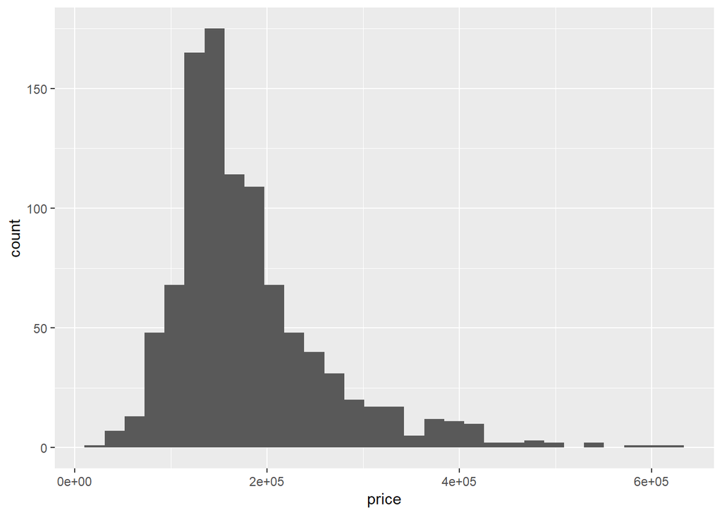

```r
ggplot(data = ames_train, aes(x = price)) +
  geom_histogram()
```

### 2.1.2 Analysing categorical variables

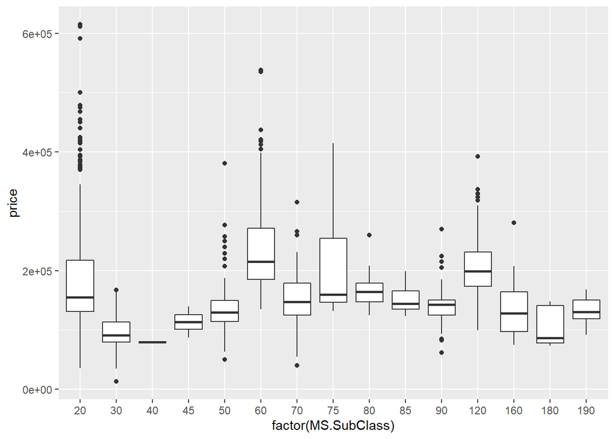

```r
ggplot(data = ames_train, aes(x = factor(MS.SubClass), y = price)) +
  geom_boxplot()
```

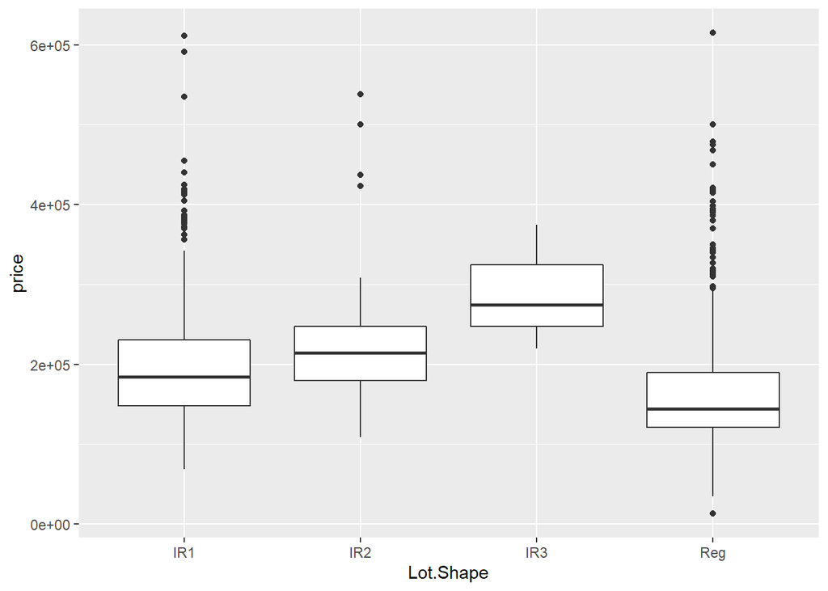

```r
ggplot(data = ames_train, aes(x = Lot.Shape, y = price)) +
  geom_boxplot()
```

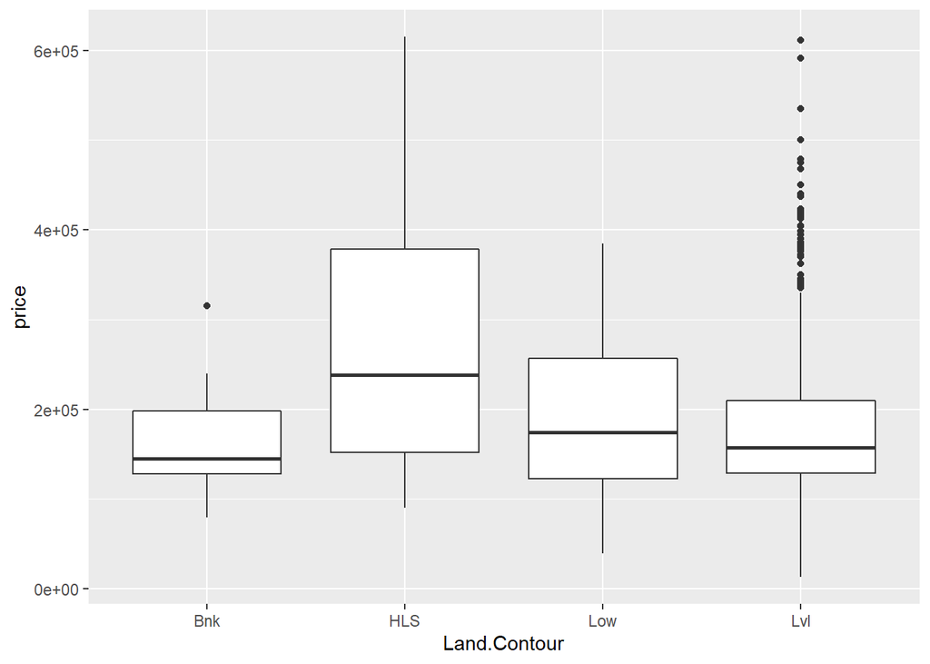

```r
ggplot(data = ames_train, aes(x = Land.Contour, y = price)) +
  geom_boxplot()
```

### 2.1.3 Analysing numerical variables

```r
correlation = ames_train %>%
  dplyr::select(price, area, Lot.Frontage, Lot.Area, Year.Built, Year.Remod.Add, Mas.Vnr.Area, BsmtFin.SF.1, BsmtFin.SF.2, Bsmt.Unf.SF, Total.Bsmt.SF, X1st.Flr.SF, X2nd.Flr.SF, Low.Qual.Fin.SF, Garage.Yr.Blt, Garage.Area, Wood.Deck.SF, Open.Porch.SF, Enclosed.Porch, X3Ssn.Porch, Screen.Porch, Pool.Area, Misc.Val, Yr.Sold) %>%
  cor()

correlation = round(correlation, 2)

correlation %>%
  as.data.frame() %>%
  rownames_to_column(var = 'var1') %>%
  gather(var2, value, -var1) %>%
  filter(value > 0.7 & value < 1)
```

```
##            var1          var2 value
## 1          area         price  0.71
## 2         price          area  0.71
## 3 Garage.Yr.Blt    Year.Built  0.83
## 4   X1st.Flr.SF Total.Bsmt.SF  0.83
## 5 Total.Bsmt.SF   X1st.Flr.SF  0.83
## 6    Year.Built Garage.Yr.Blt  0.83
```

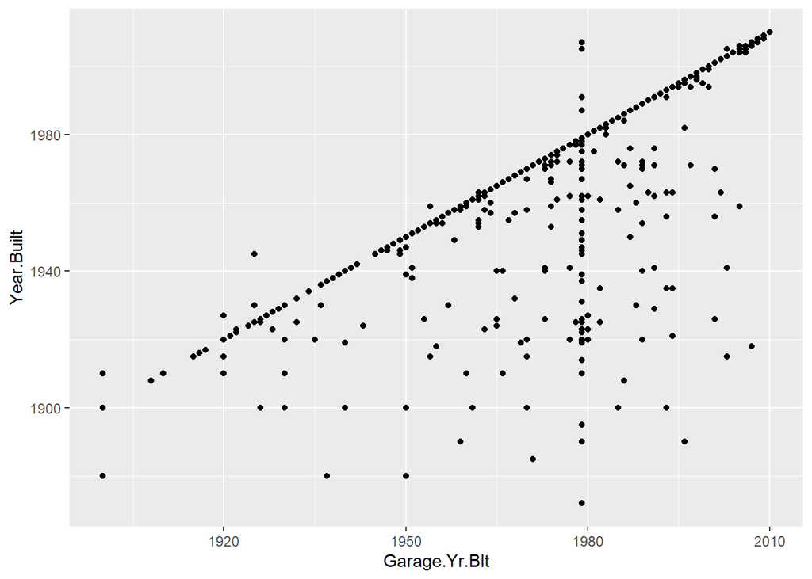

```r
ggplot(data = ames_train, aes(x = Garage.Yr.Blt, y = Year.Built)) +
  geom_point()
```

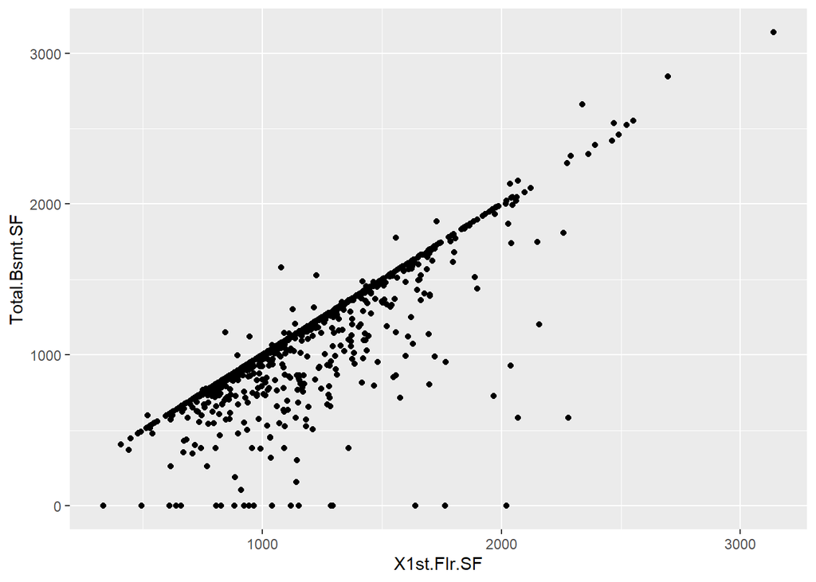

```r
ggplot(data = ames_train, aes(x = X1st.Flr.SF, y = Total.Bsmt.SF)) +
  geom_point()
```

Observations

- Garage.Yr.Blt and Year.Built variables have a strong linear correlation, so I can use one of them.
- X1st.Flr.SF and Total.Bsmt.SF variables have a strong linear correlation, so I can use one of them.

Removing Year.Built and Total.Bsmt.SF

```r
ames_train = subset(ames_train, select = -c(Year.Built, Total.Bsmt.SF))
```

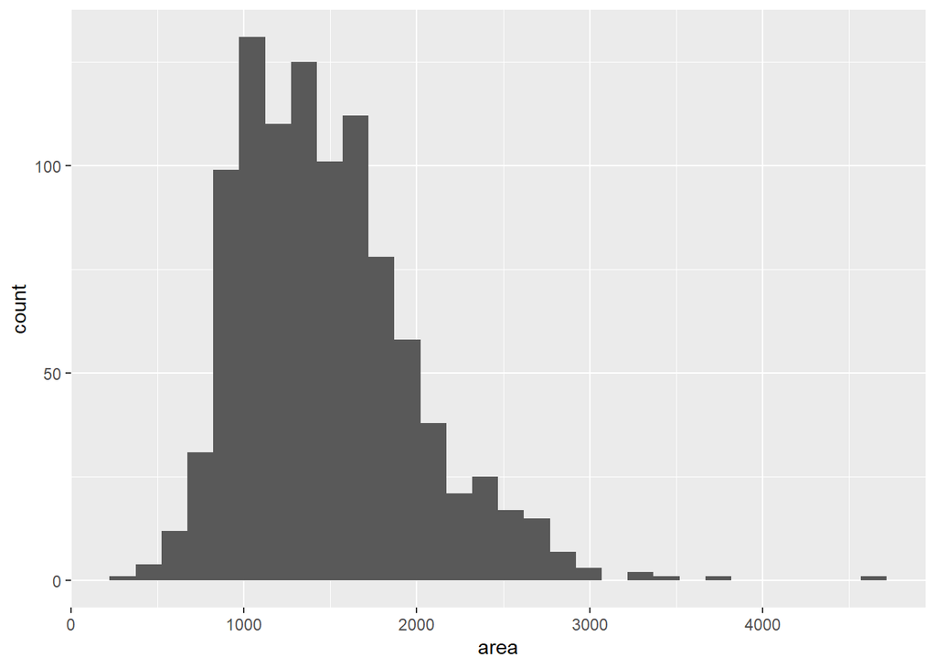

```r
ggplot(data = ames_train, aes(x = area)) +
  geom_histogram()
```

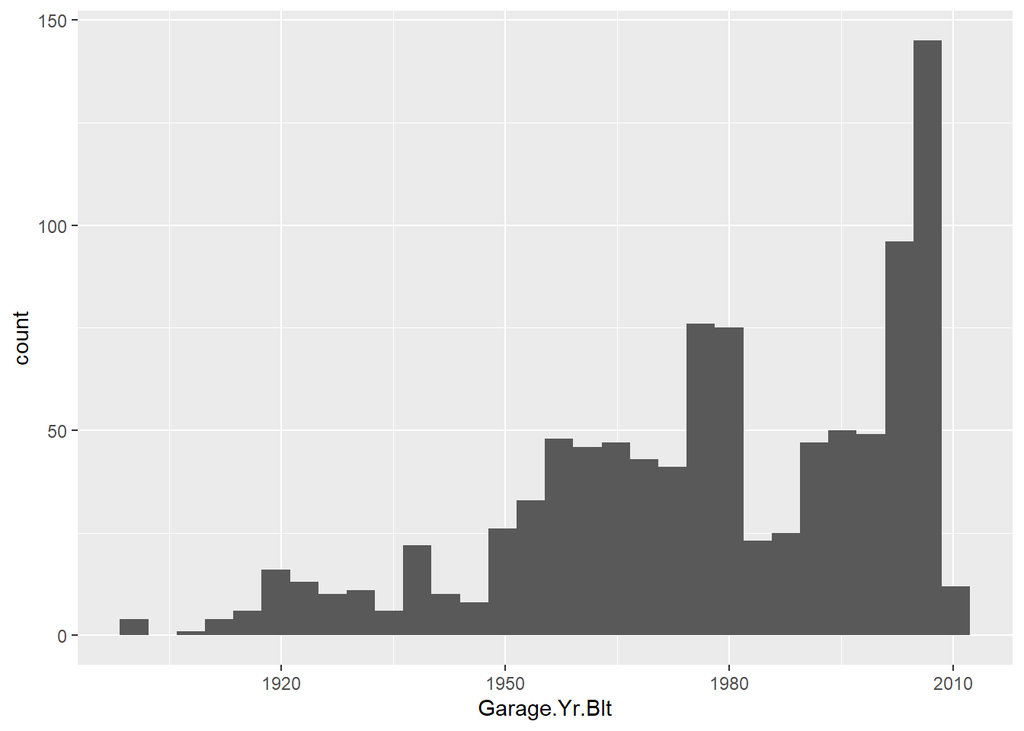

```r
ggplot(data = ames_train, aes(x = Garage.Yr.Blt)) +
  geom_histogram()
```

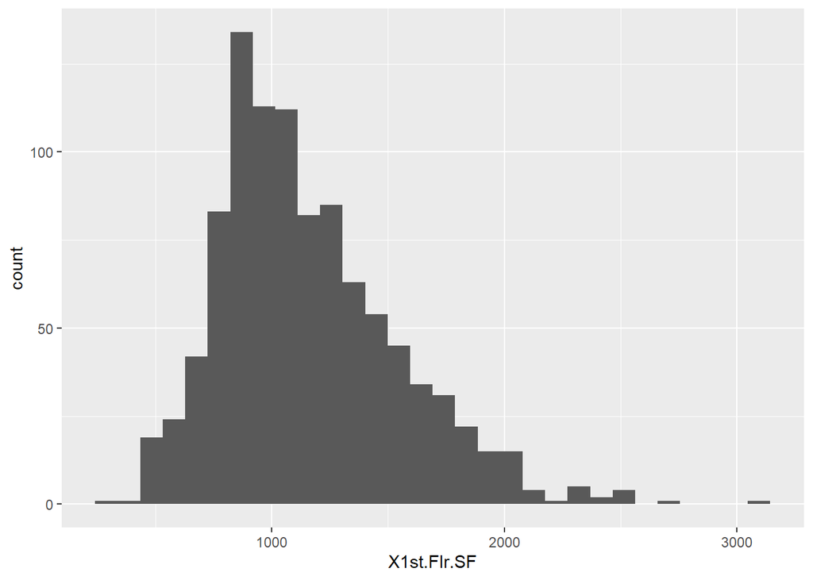

```r
ggplot(data = ames_train, aes(x = X1st.Flr.SF)) +
  geom_histogram()
```

## 2.2 Part 2 - Development and assessment of an initial model, following a semi-guided process of analysis

### 2.2.1 Section 2.1 An Initial Model

In building a model, it is often useful to start by creating a simple, intuitive initial model based on the results of the exploratory data analysis. (Note: The goal at this stage is **not** to identify the “best” possible model but rather to choose a reasonable and understandable starting point. Later you will expand and revise this model to create your final model.

Based on your EDA, select *at most* 10 predictor variables from “ames_train” and create a linear model for `price` (or a transformed version of price) using those variables. Provide the *R code* and the *summary output table* for your model, a *brief justification* for the variables you have chosen, and a *brief discussion* of the model results in context (focused on the variables that appear to be important predictors and how they relate to sales price).

```r
initial.model = lm(price ~ area + Garage.Yr.Blt + X1st.Flr.SF, data = ames_train)
summary(initial.model)
```

```
##
## Call:
## lm(formula = price ~ area + Garage.Yr.Blt + X1st.Flr.SF, data = ames_train)
##
## Residuals:
##     Min      1Q  Median      3Q     Max
## -388611  -22683   -1408   19564  251435
##
## Coefficients:
##                 Estimate Std. Error t value Pr(>|t|)
## (Intercept)   -2.008e+06  1.212e+05  -16.56   <2e-16 ***
## area           6.912e+01  3.511e+00   19.68   <2e-16 ***
## Garage.Yr.Blt  1.013e+03  6.213e+01   16.31   <2e-16 ***
## X1st.Flr.SF    7.151e+01  4.622e+00   15.47   <2e-16 ***
## ---
## Signif. codes:  0 '***' 0.001 '**' 0.01 '*' 0.05 '.' 0.1 ' ' 1
##
## Residual standard error: 45200 on 989 degrees of freedom
## Multiple R-squared:  0.6972, Adjusted R-squared:  0.6962
## F-statistic: 758.9 on 3 and 989 DF,  p-value: < 2.2e-16
```

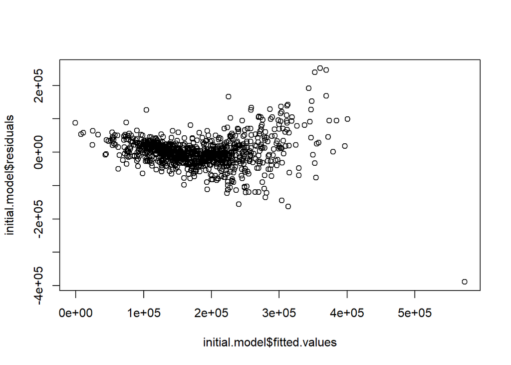

```r
plot(initial.model$residuals ~ initial.model$fitted.values)
```

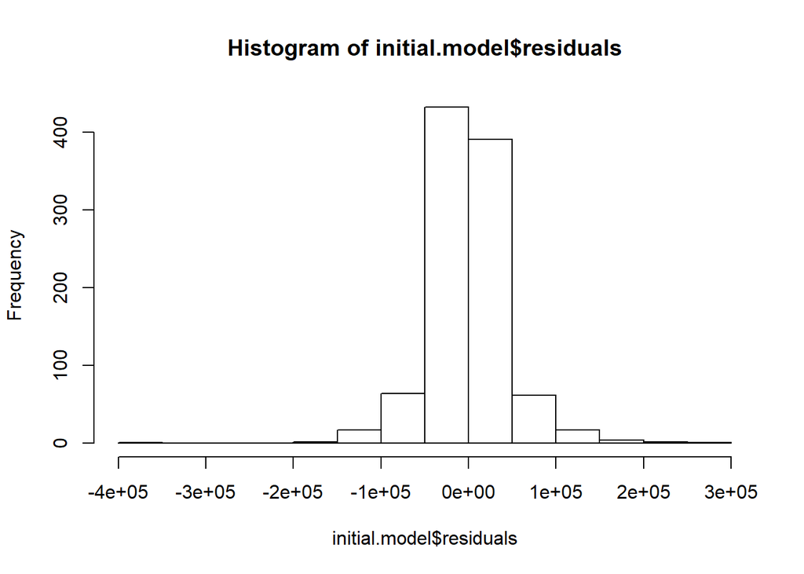

```r
hist(initial.model$residuals)
```

Observations:

- All predictors are statistically significant.
- R-squared does not look bad, due to it is greater than 0.5. So, these variables are good predictors.
- Residuals have a nearly normal distribution, but there is a correlation between residuals and fitted values.
- There is an extreme outlier.

Applying log transformation to target variable.

```r
initial.model_l = lm(log(price) ~ area + Garage.Yr.Blt + X1st.Flr.SF, data = ames_train)
summary(initial.model_l)
```

```
##
## Call:
## lm(formula = log(price) ~ area + Garage.Yr.Blt + X1st.Flr.SF,
##     data = ames_train)
##
## Residuals:
##      Min       1Q   Median       3Q      Max
## -1.92503 -0.08438  0.03211  0.13141  0.74715
##
## Coefficients:
##                 Estimate Std. Error t value Pr(>|t|)
## (Intercept)   -6.252e-01  6.138e-01  -1.019    0.309
## area           3.680e-04  1.778e-05  20.691   <2e-16 ***
## Garage.Yr.Blt  5.932e-03  3.146e-04  18.854   <2e-16 ***
## X1st.Flr.SF    3.166e-04  2.341e-05  13.524   <2e-16 ***
## ---
## Signif. codes:  0 '***' 0.001 '**' 0.01 '*' 0.05 '.' 0.1 ' ' 1
##
## Residual standard error: 0.2289 on 989 degrees of freedom
## Multiple R-squared:  0.7054, Adjusted R-squared:  0.7045
## F-statistic: 789.4 on 3 and 989 DF,  p-value: < 2.2e-16
```

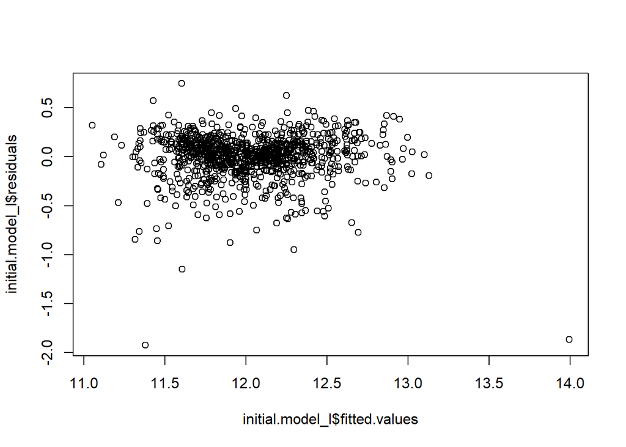

```r
plot(initial.model_l$residuals ~ initial.model_l$fitted.values)
```

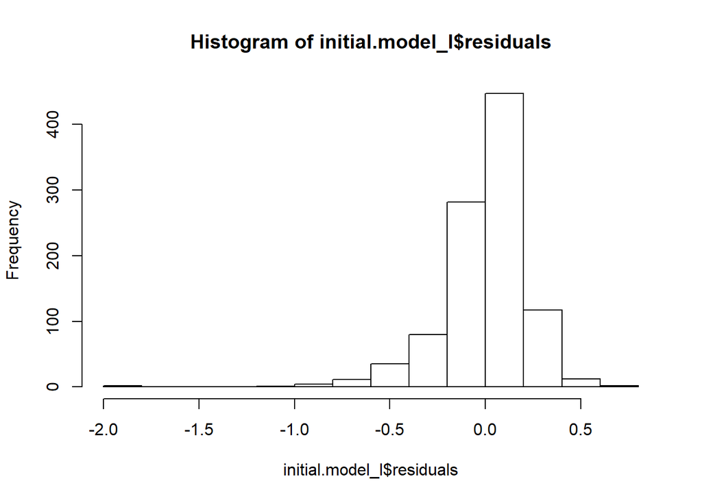

```r
hist(initial.model_l$residuals)
```

Observations:

- Using log transformation improve R-square, but not linear regression conditions for residuals.

### 2.2.2 Section 2.2 Model Selection

Now either using `BAS` another stepwise selection procedure choose the “best” model you can, using your initial model as your starting point. Try at least two different model selection methods and compare their results. Do they both arrive at the same model or do they disagree? What do you think this means?

**Remove features using p-value**

```r
library(MASS)
model.full = lm(price ~ ., data = ames_train)
summary(model.full)
```

```
##
## Call:
## lm(formula = price ~ ., data = ames_train)
##
## Residuals:
##     Min      1Q  Median      3Q     Max
## -336965  -11576       0   10939  133966
##
## Coefficients: (14 not defined because of singularities)
##                         Estimate Std. Error t value Pr(>|t|)
## (Intercept)           -3.911e+05  1.490e+06  -0.262 0.793065
## area                   1.234e+01  2.043e+01   0.604 0.546102
## MS.SubClass            8.345e+01  1.138e+02   0.733 0.463703
## Lot.Frontage          -2.656e+01  6.079e+01  -0.437 0.662245
## Lot.Area               4.693e-01  1.562e-01   3.004 0.002750 **
## Lot.ShapeIR2           3.491e+03  5.840e+03   0.598 0.550146
## Lot.ShapeIR3           4.931e+03  1.971e+04   0.250 0.802547
## Lot.ShapeReg           9.569e+02  2.198e+03   0.435 0.663499
## Land.ContourHLS        2.941e+04  7.303e+03   4.027 6.17e-05 ***
## Land.ContourLow        1.198e+04  9.739e+03   1.230 0.219093
## Land.ContourLvl        1.921e+04  5.546e+03   3.464 0.000561 ***
## Lot.ConfigCulDSac      5.239e+03  4.547e+03   1.152 0.249579
## Lot.ConfigFR2         -2.549e+03  5.503e+03  -0.463 0.643370
## Lot.ConfigFR3         -2.651e+04  1.461e+04  -1.815 0.069894 .
## Lot.ConfigInside      -2.464e+03  2.630e+03  -0.937 0.348988
## Land.SlopeMod          1.472e+04  6.183e+03   2.381 0.017499 *
## Land.SlopeSev         -9.433e+03  1.784e+04  -0.529 0.597063
## Condition.1Feedr       1.470e+04  7.870e+03   1.868 0.062068 .
## Condition.1Norm        2.397e+04  6.825e+03   3.512 0.000469 ***
## Condition.1PosA        4.054e+04  1.268e+04   3.197 0.001444 **
## Condition.1PosN       -7.691e+03  1.123e+04  -0.685 0.493657
## Condition.1RRAe        1.048e+04  1.163e+04   0.902 0.367521
## Condition.1RRAn        1.371e+04  1.098e+04   1.250 0.211834
## Condition.1RRNe        4.379e+03  2.236e+04   0.196 0.844758
## Condition.1RRNn        5.420e+03  1.726e+04   0.314 0.753622
## Bldg.Type2fmCon       -2.436e+04  1.722e+04  -1.414 0.157655
## Bldg.TypeDuplex       -1.868e+04  1.066e+04  -1.753 0.080008 .
## Bldg.TypeTwnhs        -2.362e+04  1.262e+04  -1.871 0.061724 .
## Bldg.TypeTwnhsE       -1.705e+04  1.210e+04  -1.409 0.159216
## House.Style1.5Unf     -1.671e+03  1.249e+04  -0.134 0.893566
```

[output cut: 151 more lines]

```
## Sale.TypeNew          -7.837e+03  1.905e+04  -0.411 0.680848
## Sale.TypeOth          -7.701e+03  1.545e+04  -0.498 0.618408
## Sale.TypeVWD          -1.427e+04  2.991e+04  -0.477 0.633507
## Sale.TypeWD            6.381e+02  6.080e+03   0.105 0.916433
## Sale.ConditionAdjLand  6.304e+03  2.535e+04   0.249 0.803655
## Sale.ConditionAlloca   2.748e+04  1.793e+04   1.532 0.125853
## Sale.ConditionFamily  -2.104e+04  8.237e+03  -2.554 0.010830 *
## Sale.ConditionNormal   9.452e+03  4.192e+03   2.255 0.024403 *
## Sale.ConditionPartial  3.397e+04  1.821e+04   1.866 0.062464 .
## ---
## Signif. codes:  0 '***' 0.001 '**' 0.01 '*' 0.05 '.' 0.1 ' ' 1
##
## Residual standard error: 26630 on 817 degrees of freedom
## Multiple R-squared:  0.9131, Adjusted R-squared:  0.8945
## F-statistic: 49.08 on 175 and 817 DF,  p-value: < 2.2e-16
```

```r
ames_train = subset(ames_train, select = -c(MS.SubClass, House.Style, Year.Remod.Add, Roof.Style, Exterior.1st, Exterior.2nd, Mas.Vnr.Type, Bsmt.Qual, Bsmt.Cond, Bsmt.Exposure, BsmtFin.Type.1, BsmtFin.Type.2, Heating.QC, X1st.Flr.SF, X2nd.Flr.SF, Low.Qual.Fin.SF, Bsmt.Full.Bath, Bsmt.Half.Bath, Full.Bath, Half.Bath, Bedroom.AbvGr, Kitchen.AbvGr, Functional, Fireplace.Qu, Garage.Type, Garage.Yr.Blt, Garage.Finish, Garage.Cars, Garage.Area, Garage.Qual, Garage.Cond))
```

```r
model.full.2 = lm(price ~ ., data = ames_train)
summary(model.full.2)
```

```
##
## Call:
## lm(formula = price ~ ., data = ames_train)
##
## Residuals:
##     Min      1Q  Median      3Q     Max
## -367095  -14907       0   12987  164145
##
## Coefficients:
##                         Estimate Std. Error t value Pr(>|t|)
## (Intercept)            3.109e+05  1.521e+06   0.204 0.838063
## area                   4.071e+01  4.214e+00   9.661  < 2e-16 ***
## Lot.Frontage           2.530e+01  5.844e+01   0.433 0.665185
## Lot.Area               4.450e-01  1.508e-01   2.951 0.003245 **
## Lot.ShapeIR2           5.267e+03  6.030e+03   0.874 0.382581
## Lot.ShapeIR3           2.164e+04  2.020e+04   1.072 0.284169
## Lot.ShapeReg           2.137e+03  2.265e+03   0.943 0.345792
## Land.ContourHLS        3.298e+04  7.423e+03   4.443 9.96e-06 ***
## Land.ContourLow        2.016e+04  9.639e+03   2.091 0.036794 *
## Land.ContourLvl        1.847e+04  5.569e+03   3.316 0.000947 ***
## Lot.ConfigCulDSac      7.946e+03  4.618e+03   1.721 0.085637 .
## Lot.ConfigFR2         -1.663e+03  5.626e+03  -0.296 0.767585
## Lot.ConfigFR3         -7.338e+02  1.362e+04  -0.054 0.957029
## Lot.ConfigInside      -2.789e+03  2.680e+03  -1.040 0.298412
## Land.SlopeMod          1.716e+04  6.082e+03   2.822 0.004879 **
## Land.SlopeSev         -2.498e+04  1.711e+04  -1.460 0.144600
## Condition.1Feedr       1.658e+04  7.688e+03   2.157 0.031298 *
## Condition.1Norm        2.571e+04  6.538e+03   3.933 9.02e-05 ***
## Condition.1PosA        3.371e+04  1.266e+04   2.662 0.007902 **
## Condition.1PosN        5.161e+03  1.130e+04   0.457 0.647860
## Condition.1RRAe        1.510e+04  1.118e+04   1.351 0.177101
## Condition.1RRAn        2.740e+04  1.096e+04   2.499 0.012630 *
## Condition.1RRNe       -4.763e+03  2.228e+04  -0.214 0.830736
## Condition.1RRNn       -1.763e+03  1.831e+04  -0.096 0.923303
## Bldg.Type2fmCon       -1.687e+04  7.122e+03  -2.368 0.018077 *
## Bldg.TypeDuplex       -1.064e+04  5.926e+03  -1.795 0.072950 .
## Bldg.TypeTwnhs        -1.830e+04  5.750e+03  -3.183 0.001507 **
## Bldg.TypeTwnhsE       -1.023e+04  4.122e+03  -2.481 0.013262 *
## Overall.Qual           1.437e+04  1.262e+03  11.387  < 2e-16 ***
## Overall.Cond           2.537e+03  9.727e+02   2.608 0.009249 **
```

[output cut: 33 more lines]

```
## Sale.TypeNew           1.040e+04  1.962e+04   0.530 0.596042
## Sale.TypeOth          -4.175e+03  1.594e+04  -0.262 0.793484
## Sale.TypeVWD          -1.323e+04  3.069e+04  -0.431 0.666349
## Sale.TypeWD            5.850e+03  6.173e+03   0.948 0.343467
## Sale.ConditionAdjLand -9.900e+03  2.251e+04  -0.440 0.660167
## Sale.ConditionAlloca   1.998e+04  1.567e+04   1.275 0.202718
## Sale.ConditionFamily  -1.938e+04  8.451e+03  -2.293 0.022081 *
## Sale.ConditionNormal   9.822e+03  4.225e+03   2.325 0.020301 *
## Sale.ConditionPartial  3.193e+04  1.876e+04   1.702 0.089076 .
## ---
## Signif. codes:  0 '***' 0.001 '**' 0.01 '*' 0.05 '.' 0.1 ' ' 1
##
## Residual standard error: 29100 on 921 degrees of freedom
## Multiple R-squared:  0.8831, Adjusted R-squared:  0.8741
## F-statistic:    98 on 71 and 921 DF,  p-value: < 2.2e-16
```

```r
ames_train = subset(ames_train, select = -c(Lot.Config, Fence, Misc.Val, Mo.Sold, Sale.Type))
```

```r
model.full.3 = lm(price ~ ., data = ames_train)
summary(model.full.3)
```

```
##
## Call:
## lm(formula = price ~ ., data = ames_train)
##
## Residuals:
##     Min      1Q  Median      3Q     Max
## -369617  -14969     131   12762  170323
##
## Coefficients:
##                         Estimate Std. Error t value Pr(>|t|)
## (Intercept)            8.143e+04  1.480e+06   0.055 0.956141
## area                   4.063e+01  4.175e+00   9.731  < 2e-16 ***
## Lot.Frontage           5.424e+00  5.580e+01   0.097 0.922586
## Lot.Area               4.591e-01  1.499e-01   3.062 0.002258 **
## Lot.ShapeIR2           8.160e+03  5.880e+03   1.388 0.165554
## Lot.ShapeIR3           2.219e+04  2.012e+04   1.103 0.270154
## Lot.ShapeReg           4.300e+02  2.145e+03   0.200 0.841177
## Land.ContourHLS        3.329e+04  7.361e+03   4.523 6.89e-06 ***
## Land.ContourLow        2.110e+04  9.564e+03   2.206 0.027599 *
## Land.ContourLvl        1.904e+04  5.531e+03   3.443 0.000601 ***
## Land.SlopeMod          1.667e+04  6.036e+03   2.762 0.005850 **
## Land.SlopeSev         -2.391e+04  1.705e+04  -1.402 0.161292
## Condition.1Feedr       1.594e+04  7.544e+03   2.113 0.034898 *
## Condition.1Norm        2.505e+04  6.452e+03   3.882 0.000111 ***
## Condition.1PosA        3.207e+04  1.256e+04   2.554 0.010805 *
## Condition.1PosN        5.933e+03  1.120e+04   0.530 0.596492
## Condition.1RRAe        1.461e+04  1.100e+04   1.328 0.184645
## Condition.1RRAn        2.689e+04  1.089e+04   2.470 0.013684 *
## Condition.1RRNe       -3.039e+03  2.217e+04  -0.137 0.890998
## Condition.1RRNn       -1.575e+03  1.823e+04  -0.086 0.931163
## Bldg.Type2fmCon       -1.560e+04  7.044e+03  -2.215 0.027025 *
## Bldg.TypeDuplex       -1.112e+04  5.794e+03  -1.919 0.055267 .
## Bldg.TypeTwnhs        -1.941e+04  5.702e+03  -3.405 0.000690 ***
## Bldg.TypeTwnhsE       -1.103e+04  4.067e+03  -2.711 0.006826 **
## Overall.Qual           1.468e+04  1.248e+03  11.766  < 2e-16 ***
## Overall.Cond           2.613e+03  9.558e+02   2.734 0.006371 **
## Mas.Vnr.Area           3.046e+01  6.381e+00   4.773 2.10e-06 ***
## Exter.QualFa          -5.189e+04  1.228e+04  -4.227 2.60e-05 ***
## Exter.QualGd          -3.778e+04  6.969e+03  -5.420 7.56e-08 ***
## Exter.QualTA          -5.366e+04  7.751e+03  -6.924 8.14e-12 ***
```

[output cut: 14 more lines]

```
## X3Ssn.Porch            1.824e+01  3.264e+01   0.559 0.576360
## Screen.Porch           4.613e+01  1.810e+01   2.549 0.010961 *
## Pool.Area             -7.095e+01  3.276e+01  -2.166 0.030567 *
## Yr.Sold               -4.479e+01  7.371e+02  -0.061 0.951560
## Sale.ConditionAdjLand -4.399e+03  2.231e+04  -0.197 0.843740
## Sale.ConditionAlloca   2.102e+04  1.546e+04   1.359 0.174373
## Sale.ConditionFamily  -1.829e+04  8.245e+03  -2.218 0.026775 *
## Sale.ConditionNormal   1.089e+04  4.000e+03   2.722 0.006612 **
## Sale.ConditionPartial  3.752e+04  5.501e+03   6.820 1.62e-11 ***
## ---
## Signif. codes:  0 '***' 0.001 '**' 0.01 '*' 0.05 '.' 0.1 ' ' 1
##
## Residual standard error: 29100 on 940 degrees of freedom
## Multiple R-squared:  0.8807, Adjusted R-squared:  0.8741
## F-statistic: 133.4 on 52 and 940 DF,  p-value: < 2.2e-16
```

**Remove features using AIC**

```r
model.AIC <- stepAIC(model.full.3, k = 2)
```

```
## Start:  AIC=20464.95
## price ~ area + Lot.Frontage + Lot.Area + Lot.Shape + Land.Contour +
##     Land.Slope + Condition.1 + Bldg.Type + Overall.Qual + Overall.Cond +
##     Mas.Vnr.Area + Exter.Qual + BsmtFin.SF.1 + BsmtFin.SF.2 +
##     Bsmt.Unf.SF + Kitchen.Qual + TotRms.AbvGrd + Fireplaces +
##     Paved.Drive + Wood.Deck.SF + Open.Porch.SF + Enclosed.Porch +
##     X3Ssn.Porch + Screen.Porch + Pool.Area + Yr.Sold + Sale.Condition
##
##                  Df  Sum of Sq        RSS   AIC
## - Lot.Shape       3 2.3525e+09 7.9862e+11 20462
## - Yr.Sold         1 3.1277e+06 7.9627e+11 20463
## - Lot.Frontage    1 8.0036e+06 7.9627e+11 20463
## - TotRms.AbvGrd   1 2.3798e+07 7.9629e+11 20463
## - X3Ssn.Porch     1 2.6461e+08 7.9653e+11 20463
## - Paved.Drive     2 2.4607e+09 7.9872e+11 20464
## - Open.Porch.SF   1 1.3928e+09 7.9766e+11 20465
## <none>                         7.9626e+11 20465
## - Enclosed.Porch  1 1.8151e+09 7.9808e+11 20465
## - Pool.Area       1 3.9739e+09 8.0024e+11 20468
## - Screen.Porch    1 5.5040e+09 8.0177e+11 20470
## - Overall.Cond    1 6.3327e+09 8.0260e+11 20471
## - Land.Slope      2 9.3810e+09 8.0564e+11 20473
## - Lot.Area        1 7.9441e+09 8.0421e+11 20473
## - Wood.Deck.SF    1 9.5601e+09 8.0582e+11 20475
## - Condition.1     8 2.4066e+10 8.2033e+11 20479
## - Land.Contour    3 1.7602e+10 8.1387e+11 20481
## - Fireplaces      1 1.4525e+10 8.1079e+11 20481
## - Bldg.Type       4 1.9932e+10 8.1620e+11 20482
## - BsmtFin.SF.2    1 1.9048e+10 8.1531e+11 20486
## - Mas.Vnr.Area    1 1.9300e+10 8.1556e+11 20487
## - Bsmt.Unf.SF     1 2.4338e+10 8.2060e+11 20493
## - Kitchen.Qual    4 3.9167e+10 8.3543e+11 20505
## - Exter.Qual      3 4.3751e+10 8.4002e+11 20512
## - Sale.Condition  5 6.1474e+10 8.5774e+11 20529
## - area            1 8.0220e+10 8.7648e+11 20558
## - Overall.Qual    1 1.1727e+11 9.1353e+11 20599
## - BsmtFin.SF.1    1 1.4410e+11 9.4037e+11 20628
##
## Step:  AIC=20461.88
## price ~ area + Lot.Frontage + Lot.Area + Land.Contour + Land.Slope +
```

[output cut: 188 more lines]

```
## - Wood.Deck.SF    1 1.0102e+10 8.1161e+11 20464
## - Condition.1     8 2.4640e+10 8.2615e+11 20468
## - Fireplaces      1 1.4642e+10 8.1615e+11 20469
## - Lot.Area        1 1.4717e+10 8.1622e+11 20470
## - Land.Contour    3 1.9481e+10 8.2099e+11 20471
## - Bldg.Type       4 2.3475e+10 8.2498e+11 20474
## - Mas.Vnr.Area    1 1.8706e+10 8.2021e+11 20474
## - BsmtFin.SF.2    1 2.0790e+10 8.2230e+11 20477
## - Bsmt.Unf.SF     1 2.5000e+10 8.2651e+11 20482
## - Kitchen.Qual    4 3.8901e+10 8.4041e+11 20493
## - Exter.Qual      3 4.4428e+10 8.4594e+11 20501
## - Sale.Condition  5 6.4053e+10 8.6556e+11 20520
## - Overall.Qual    1 1.2377e+11 9.2528e+11 20594
## - BsmtFin.SF.1    1 1.5718e+11 9.5869e+11 20629
## - area            1 1.6578e+11 9.6728e+11 20638
```

Observations:

- Based on AIC method, the best model has the following features: Open.Porch.SF, Enclosed.Porch, Pool.Area, Screen.Porch, Overall.Cond, Land.Slope, Wood.Deck.SF, Condition.1, Fireplaces, Lot.Area, Land.Contour, Bldg.Type, Mas.Vnr.Area, BsmtFin.SF.2, Bsmt.Unf.SF, Kitchen.Qual, Exter.Qual, Sale.Condition, Overall.Qual, BsmtFin.SF.1, area and price.

### 2.2.3 Section 2.3 Initial Model Residuals

One way to assess the performance of a model is to examine the model’s residuals. In the space below, create a residual plot for your preferred model from above and use it to assess whether your model appears to fit the data well. Comment on any interesting structure in the residual plot (trend, outliers, etc.) and briefly discuss potential implications it may have for your model and inference / prediction you might produce.

```r
ames_train = ames_train %>%
  dplyr::select(price, Open.Porch.SF, Enclosed.Porch, Pool.Area, Screen.Porch, Overall.Cond, Land.Slope, Wood.Deck.SF, Condition.1, Fireplaces, Lot.Area, Land.Contour, Bldg.Type, Mas.Vnr.Area, BsmtFin.SF.2, Bsmt.Unf.SF, Kitchen.Qual, Exter.Qual, Sale.Condition, Overall.Qual, BsmtFin.SF.1, area)

head(ames_train)
```

```
## # A tibble: 6 x 22
##    price Open.Porch.SF Enclosed.Porch Pool.Area Screen.Porch Overall.Cond
##    <int>         <int>          <int>     <int>        <int>        <int>
## 1 126000             0              0         0          166            6
## 2 139500           105              0         0            0            5
## 3 124900             0             42         0            0            9
## 4 114000             0            168         0          111            8
## 5 227000            45              0         0            0            6
## 6 198500             0            177         0            0            5
## # ... with 16 more variables: Land.Slope <fct>, Wood.Deck.SF <int>,
## #   Condition.1 <fct>, Fireplaces <int>, Lot.Area <int>, Land.Contour <fct>,
## #   Bldg.Type <fct>, Mas.Vnr.Area <dbl>, BsmtFin.SF.2 <int>, Bsmt.Unf.SF <int>,
## #   Kitchen.Qual <fct>, Exter.Qual <fct>, Sale.Condition <fct>,
## #   Overall.Qual <int>, BsmtFin.SF.1 <int>, area <int>
```

```r
model.best = lm(price ~ ., data = ames_train)
summary(model.best)
```

```
##
## Call:
## lm(formula = price ~ ., data = ames_train)
##
## Residuals:
##     Min      1Q  Median      3Q     Max
## -372547  -14941     122   12986  166096
##
## Coefficients:
##                         Estimate Std. Error t value Pr(>|t|)
## (Intercept)           -6.912e+03  1.555e+04  -0.445 0.656746
## Open.Porch.SF         -2.207e+01  1.510e+01  -1.461 0.144214
## Enclosed.Porch        -3.056e+01  1.654e+01  -1.847 0.065024 .
## Pool.Area             -7.134e+01  3.261e+01  -2.188 0.028924 *
## Screen.Porch           4.460e+01  1.800e+01   2.478 0.013393 *
## Overall.Cond           2.522e+03  9.477e+02   2.661 0.007921 **
## Land.SlopeMod          1.776e+04  5.978e+03   2.972 0.003035 **
## Land.SlopeSev         -2.130e+04  1.689e+04  -1.261 0.207755
## Wood.Deck.SF           2.964e+01  8.569e+00   3.459 0.000567 ***
## Condition.1Feedr       1.644e+04  7.476e+03   2.199 0.028139 *
## Condition.1Norm        2.550e+04  6.386e+03   3.993 7.03e-05 ***
## Condition.1PosA        3.332e+04  1.226e+04   2.718 0.006690 **
## Condition.1PosN        6.714e+03  1.112e+04   0.604 0.546294
## Condition.1RRAe        1.527e+04  1.087e+04   1.404 0.160595
## Condition.1RRAn        2.855e+04  1.068e+04   2.673 0.007642 **
## Condition.1RRNe       -2.414e+03  2.170e+04  -0.111 0.911456
## Condition.1RRNn        1.140e+03  1.807e+04   0.063 0.949703
## Fireplaces             7.472e+03  1.795e+03   4.164 3.42e-05 ***
## Lot.Area               5.496e-01  1.317e-01   4.174 3.26e-05 ***
## Land.ContourHLS        3.455e+04  7.251e+03   4.765 2.18e-06 ***
## Land.ContourLow        2.000e+04  9.521e+03   2.101 0.035893 *
## Land.ContourLvl        2.008e+04  5.459e+03   3.678 0.000249 ***
## Bldg.Type2fmCon       -1.631e+04  6.945e+03  -2.348 0.019081 *
## Bldg.TypeDuplex       -1.120e+04  5.560e+03  -2.015 0.044220 *
## Bldg.TypeTwnhs        -1.881e+04  5.088e+03  -3.698 0.000230 ***
## Bldg.TypeTwnhsE       -1.051e+04  3.692e+03  -2.846 0.004520 **
## Mas.Vnr.Area           2.971e+01  6.313e+00   4.706 2.90e-06 ***
## BsmtFin.SF.2           3.043e+01  6.134e+00   4.961 8.29e-07 ***
## Bsmt.Unf.SF            1.848e+01  3.397e+00   5.441 6.76e-08 ***
## Kitchen.QualFa        -3.614e+04  8.968e+03  -4.030 6.04e-05 ***
## Kitchen.QualGd        -2.838e+04  5.173e+03  -5.486 5.27e-08 ***
## Kitchen.QualPo        -3.145e+04  3.006e+04  -1.046 0.295771
## Kitchen.QualTA        -3.919e+04  5.818e+03  -6.737 2.81e-11 ***
## Exter.QualFa          -5.161e+04  1.221e+04  -4.226 2.60e-05 ***
## Exter.QualGd          -3.726e+04  6.923e+03  -5.383 9.26e-08 ***
## Exter.QualTA          -5.351e+04  7.701e+03  -6.948 6.86e-12 ***
## Sale.ConditionAdjLand -2.856e+03  2.218e+04  -0.129 0.897583
## Sale.ConditionAlloca   1.949e+04  1.535e+04   1.270 0.204354
## Sale.ConditionFamily  -1.892e+04  8.206e+03  -2.305 0.021366 *
## Sale.ConditionNormal   1.053e+04  3.978e+03   2.646 0.008285 **
## Sale.ConditionPartial  3.768e+04  5.457e+03   6.905 9.20e-12 ***
## Overall.Qual           1.484e+04  1.226e+03  12.106  < 2e-16 ***
## BsmtFin.SF.1           4.438e+01  3.253e+00  13.642  < 2e-16 ***
## area                   4.125e+01  2.944e+00  14.010  < 2e-16 ***
## ---
## Signif. codes:  0 '***' 0.001 '**' 0.01 '*' 0.05 '.' 0.1 ' ' 1
##
## Residual standard error: 29060 on 949 degrees of freedom
## Multiple R-squared:  0.8799, Adjusted R-squared:  0.8744
## F-statistic: 161.6 on 43 and 949 DF,  p-value: < 2.2e-16
```

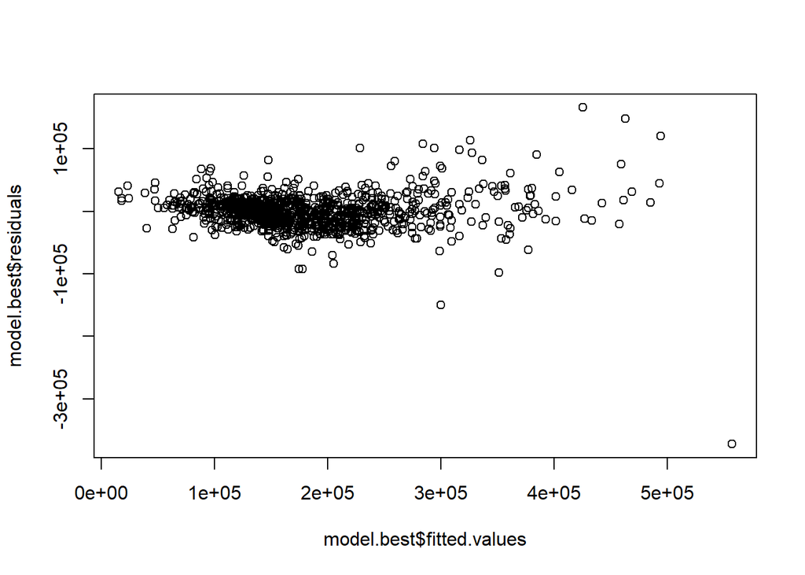

```r
plot(model.best$residuals ~ model.best$fitted.values)
```

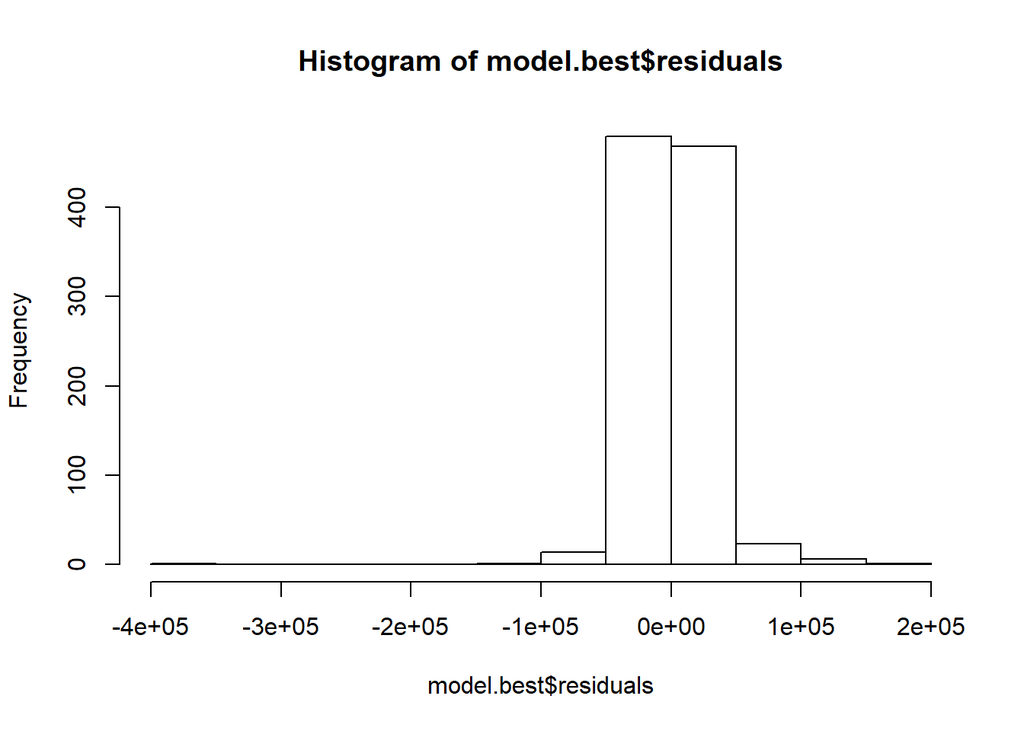

```r
hist(model.best$residuals)
```

Observations:

```r
idOutlier = which(model.best$residuals == min(model.best$residuals))
ames_train[idOutlier,]
```

```
## # A tibble: 1 x 22
##    price Open.Porch.SF Enclosed.Porch Pool.Area Screen.Porch Overall.Cond
##    <int>         <int>          <int>     <int>        <int>        <int>
## 1 184750           406              0         0            0            5
## # ... with 16 more variables: Land.Slope <fct>, Wood.Deck.SF <int>,
## #   Condition.1 <fct>, Fireplaces <int>, Lot.Area <int>, Land.Contour <fct>,
## #   Bldg.Type <fct>, Mas.Vnr.Area <dbl>, BsmtFin.SF.2 <int>, Bsmt.Unf.SF <int>,
## #   Kitchen.Qual <fct>, Exter.Qual <fct>, Sale.Condition <fct>,
## #   Overall.Qual <int>, BsmtFin.SF.1 <int>, area <int>
```

```r
ames_train = ames_train[-c(idOutlier),]
```

```r
model.best = lm(price ~ ., data = ames_train)
```

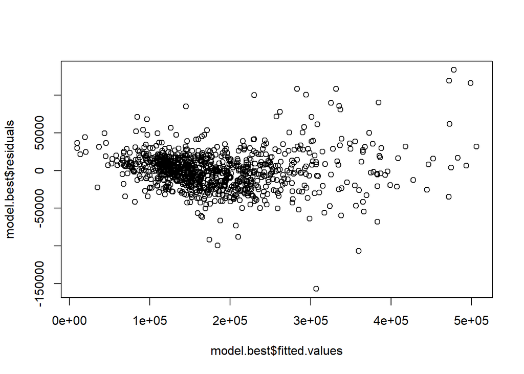

```r
plot(model.best$residuals ~ model.best$fitted.values)
```

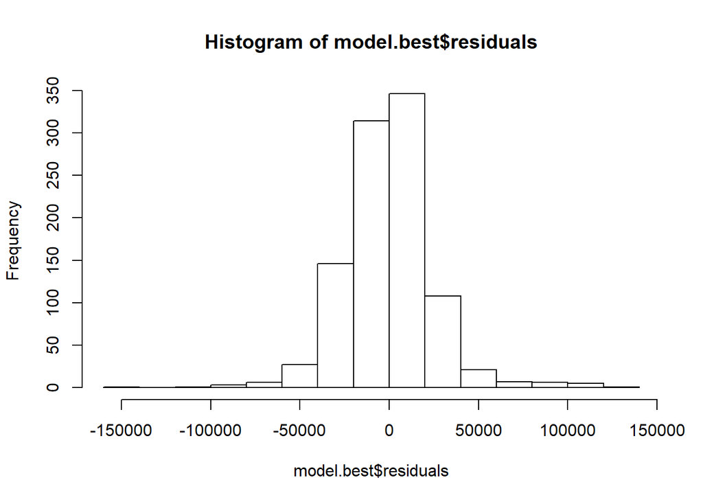

```r
hist(model.best$residuals)
```

### 2.2.4 Section 2.4 Initial Model RMSE

You can calculate it directly based on the model output. Be specific about the units of your RMSE (depending on whether you transformed your response variable). The value you report will be more meaningful if it is in the original units (dollars).

```r
# Extract Predictions
predict.best <- predict(model.best, ames_train)

# Extract Residuals
resid.best <- ames_train$price - predict.best

# Calculate RMSE
resid.best <- sqrt(mean(resid.best^2))
resid.best
```

```
## [1] 25195.41
```

### 2.2.5 Section 2.5 Overfitting

The process of building a model generally involves starting with an initial model (as you have done above), identifying its shortcomings, and adapting the model accordingly. This process may be repeated several times until the model fits the data reasonably well. However, the model may do well on training data but perform poorly out-of-sample (meaning, on a dataset other than the original training data) because the model is overly-tuned to specifically fit the training data. This is called “overfitting.” To determine whether overfitting is occurring on a model, compare the performance of a model on both in-sample and out-of-sample data sets. To look at performance of your initial model on out-of-sample data, you will use the data set `ames_test`.

```r
load("ames_test.Rdata")
```

```r
ames_test = ames_test %>%
  dplyr::select(price, Open.Porch.SF, Enclosed.Porch, Pool.Area, Screen.Porch, Overall.Cond, Land.Slope, Wood.Deck.SF, Condition.1, Fireplaces, Lot.Area, Land.Contour, Bldg.Type, Mas.Vnr.Area, BsmtFin.SF.2, Bsmt.Unf.SF, Kitchen.Qual, Exter.Qual, Sale.Condition, Overall.Qual, BsmtFin.SF.1, area)

summary(ames_test)
```

```
##      price        Open.Porch.SF    Enclosed.Porch      Pool.Area
##  Min.   : 52000   Min.   :  0.00   Min.   :   0.00   Min.   :  0.000
##  1st Qu.:133500   1st Qu.:  0.00   1st Qu.:   0.00   1st Qu.:  0.000
##  Median :162500   Median : 24.00   Median :   0.00   Median :  0.000
##  Mean   :179640   Mean   : 42.28   Mean   :  23.64   Mean   :  1.616
##  3rd Qu.:214000   3rd Qu.: 63.00   3rd Qu.:   0.00   3rd Qu.:  0.000
##  Max.   :755000   Max.   :382.00   Max.   :1012.00   Max.   :648.000
##
##   Screen.Porch     Overall.Cond   Land.Slope  Wood.Deck.SF      Condition.1
##  Min.   :  0.00   Min.   :1.000   Gtl:773    Min.   :   0.00   Norm   :700
##  1st Qu.:  0.00   1st Qu.:5.000   Mod: 38    1st Qu.:   0.00   Feedr  : 45
##  Median :  0.00   Median :5.000   Sev:  6    Median :   0.00   Artery : 27
##  Mean   : 17.41   Mean   :5.668              Mean   :  97.45   PosN   : 15
##  3rd Qu.:  0.00   3rd Qu.:6.000              3rd Qu.: 168.00   RRAn   : 12
##  Max.   :490.00   Max.   :9.000              Max.   :1424.00   RRAe   :  8
##                                                                (Other): 10
##    Fireplaces       Lot.Area      Land.Contour  Bldg.Type    Mas.Vnr.Area
##  Min.   :0.000   Min.   :  1300   Bnk: 31      1Fam  :684   Min.   :   0.0
##  1st Qu.:0.000   1st Qu.:  7472   HLS: 31      2fmCon: 11   1st Qu.:   0.0
##  Median :1.000   Median :  9375   Low: 20      Duplex: 23   Median :   0.0
##  Mean   :0.645   Mean   : 10047   Lvl:735      Twnhs : 33   Mean   :  98.7
##  3rd Qu.:1.000   3rd Qu.: 11426                TwnhsE: 66   3rd Qu.: 161.0
##  Max.   :3.000   Max.   :164660                             Max.   :1600.0
##                                                             NA's   :4
##   BsmtFin.SF.2     Bsmt.Unf.SF     Kitchen.Qual Exter.Qual Sale.Condition
##  Min.   :   0.0   Min.   :   0.0   Ex: 34       Ex: 13     Abnorml:  0
##  1st Qu.:   0.0   1st Qu.: 203.0   Fa: 19       Fa:  9     AdjLand:  0
##  Median :   0.0   Median : 437.0   Gd:333       Gd:274     Alloca :  0
##  Mean   :  52.6   Mean   : 518.5   Po:  0       TA:521     Family :  0
##  3rd Qu.:   0.0   3rd Qu.: 756.0   TA:431                  Normal :817
##  Max.   :1474.0   Max.   :2062.0                           Partial:  0
##
##   Overall.Qual     BsmtFin.SF.1         area
##  Min.   : 1.000   Min.   :   0.0   Min.   : 438
##  1st Qu.: 5.000   1st Qu.:   0.0   1st Qu.:1152
##  Median : 6.000   Median : 410.0   Median :1479
##  Mean   : 6.062   Mean   : 446.8   Mean   :1519
##  3rd Qu.: 7.000   3rd Qu.: 728.0   3rd Qu.:1743
##  Max.   :10.000   Max.   :2288.0   Max.   :4316
##
```

```r
sapply(ames_test, function(x) sum(is.na(x)))
```

```
##          price  Open.Porch.SF Enclosed.Porch      Pool.Area   Screen.Porch
##              0              0              0              0              0
##   Overall.Cond     Land.Slope   Wood.Deck.SF    Condition.1     Fireplaces
##              0              0              0              0              0
##       Lot.Area   Land.Contour      Bldg.Type   Mas.Vnr.Area   BsmtFin.SF.2
##              0              0              0              4              0
##    Bsmt.Unf.SF   Kitchen.Qual     Exter.Qual Sale.Condition   Overall.Qual
##              0              0              0              0              0
##   BsmtFin.SF.1           area
##              0              0
```

```r
summarise.1 = ames_test %>%
  filter(!is.na(Mas.Vnr.Area)) %>%
  summarise(mean = mean(Mas.Vnr.Area), median = median(Mas.Vnr.Area))

ames_test = ames_test %>%
  mutate(Mas.Vnr.Area = ifelse(is.na(Mas.Vnr.Area), summarise.1$median, Mas.Vnr.Area))
```

```r
sapply(ames_test, function(x) sum(is.na(x)))
```

```
##          price  Open.Porch.SF Enclosed.Porch      Pool.Area   Screen.Porch
##              0              0              0              0              0
##   Overall.Cond     Land.Slope   Wood.Deck.SF    Condition.1     Fireplaces
##              0              0              0              0              0
##       Lot.Area   Land.Contour      Bldg.Type   Mas.Vnr.Area   BsmtFin.SF.2
##              0              0              0              0              0
##    Bsmt.Unf.SF   Kitchen.Qual     Exter.Qual Sale.Condition   Overall.Qual
##              0              0              0              0              0
##   BsmtFin.SF.1           area
##              0              0
```

Use your model from above to generate predictions for the housing prices in the test data set. Are the predictions significantly more accurate (compared to the actual sales prices) for the training data than the test data? Why or why not? Briefly explain how you determined that (what steps or processes did you use)?

```r
# Extract Predictions
predict.test <- predict(model.best, ames_test)

resid.test <- ames_test$price - predict.test

# Calculate RMSE
resid.best <- sqrt(mean(resid.test^2))
resid.best
```

```
## [1] 25001.09
```

Observations:

- RMSE for training is greater than testing, so there is no overfitting. In fact, both RMSE are similar, so I ca say that this model is good.

**Note to the learner:** If in real-life practice this out-of-sample analysis shows evidence that the training data fits your model a lot better than the test data, it is probably a good idea to go back and revise the model (usually by simplifying the model) to reduce this overfitting. For simplicity, we do not ask you to do this on the assignment, however.

## 2.3 Part 3 Development of a Final Model

Now that you have developed an initial model to use as a baseline, create a final model with *at most* 20 variables to predict housing prices in Ames, IA, selecting from the full array of variables in the dataset and using any of the tools that we introduced in this specialization.

Carefully document the process that you used to come up with your final model, so that you can answer the questions below.

### 2.3.1 Section 3.1 Final Model

Provide the summary table for your model.

```r
model.final = lm(price ~ ., data = ames_train)
summary(model.final)
```

```
##
## Call:
## lm(formula = price ~ ., data = ames_train)
##
## Residuals:
##     Min      1Q  Median      3Q     Max
## -156889  -14267     -29   12938  133569
##
## Coefficients:
##                         Estimate Std. Error t value Pr(>|t|)
## (Intercept)            3.993e+03  1.381e+04   0.289 0.772488
## Open.Porch.SF         -4.663e+00  1.344e+01  -0.347 0.728659
## Enclosed.Porch        -3.455e+01  1.467e+01  -2.354 0.018756 *
## Pool.Area             -6.998e+01  2.892e+01  -2.420 0.015703 *
## Screen.Porch           3.473e+01  1.597e+01   2.174 0.029932 *
## Overall.Cond           2.921e+03  8.408e+02   3.474 0.000536 ***
## Land.SlopeMod          1.379e+04  5.307e+03   2.598 0.009523 **
## Land.SlopeSev         -2.992e+04  1.499e+04  -1.996 0.046209 *
## Wood.Deck.SF           2.505e+01  7.605e+00   3.294 0.001024 **
## Condition.1Feedr       1.532e+04  6.631e+03   2.310 0.021106 *
## Condition.1Norm        2.406e+04  5.664e+03   4.248 2.37e-05 ***
## Condition.1PosA        2.933e+04  1.088e+04   2.697 0.007120 **
## Condition.1PosN        3.913e+04  1.007e+04   3.886 0.000109 ***
## Condition.1RRAe        1.491e+04  9.642e+03   1.546 0.122482
## Condition.1RRAn        2.625e+04  9.474e+03   2.771 0.005694 **
## Condition.1RRNe       -8.099e+02  1.925e+04  -0.042 0.966444
## Condition.1RRNn       -2.317e+02  1.603e+04  -0.014 0.988469
## Fireplaces             4.484e+03  1.602e+03   2.798 0.005242 **
## Lot.Area               6.381e-01  1.169e-01   5.459 6.10e-08 ***
## Land.ContourHLS        2.070e+04  6.488e+03   3.191 0.001464 **
## Land.ContourLow        7.627e+03  8.479e+03   0.900 0.368585
## Land.ContourLvl        6.286e+03  4.917e+03   1.279 0.201379
## Bldg.Type2fmCon       -1.853e+04  6.161e+03  -3.007 0.002707 **
## Bldg.TypeDuplex       -1.367e+04  4.934e+03  -2.771 0.005689 **
## Bldg.TypeTwnhs        -1.621e+04  4.515e+03  -3.589 0.000348 ***
## Bldg.TypeTwnhsE       -7.332e+03  3.280e+03  -2.235 0.025641 *
## Mas.Vnr.Area           3.099e+01  5.600e+00   5.534 4.06e-08 ***
## BsmtFin.SF.2           3.177e+01  5.441e+00   5.840 7.18e-09 ***
## Bsmt.Unf.SF            1.914e+01  3.013e+00   6.354 3.26e-10 ***
## Kitchen.QualFa        -3.381e+04  7.954e+03  -4.250 2.34e-05 ***
## Kitchen.QualGd        -2.816e+04  4.587e+03  -6.139 1.22e-09 ***
## Kitchen.QualPo        -2.632e+04  2.666e+04  -0.987 0.323877
## Kitchen.QualTA        -3.719e+04  5.161e+03  -7.206 1.17e-12 ***
## Exter.QualFa          -5.851e+04  1.084e+04  -5.399 8.48e-08 ***
## Exter.QualGd          -4.323e+04  6.151e+03  -7.028 4.00e-12 ***
## Exter.QualTA          -5.921e+04  6.839e+03  -8.657  < 2e-16 ***
## Sale.ConditionAdjLand -1.127e+04  1.968e+04  -0.573 0.567026
## Sale.ConditionAlloca   1.913e+04  1.361e+04   1.405 0.160338
## Sale.ConditionFamily  -1.688e+04  7.279e+03  -2.319 0.020609 *
## Sale.ConditionNormal   1.073e+04  3.528e+03   3.042 0.002416 **
## Sale.ConditionPartial  4.171e+04  4.846e+03   8.606  < 2e-16 ***
## Overall.Qual           1.380e+04  1.089e+03  12.670  < 2e-16 ***
## BsmtFin.SF.1           4.869e+01  2.898e+00  16.802  < 2e-16 ***
## area                   4.802e+01  2.645e+00  18.156  < 2e-16 ***
## ---
## Signif. codes:  0 '***' 0.001 '**' 0.01 '*' 0.05 '.' 0.1 ' ' 1
##
## Residual standard error: 25770 on 948 degrees of freedom
## Multiple R-squared:  0.9056, Adjusted R-squared:  0.9013
## F-statistic: 211.5 on 43 and 948 DF,  p-value: < 2.2e-16
```

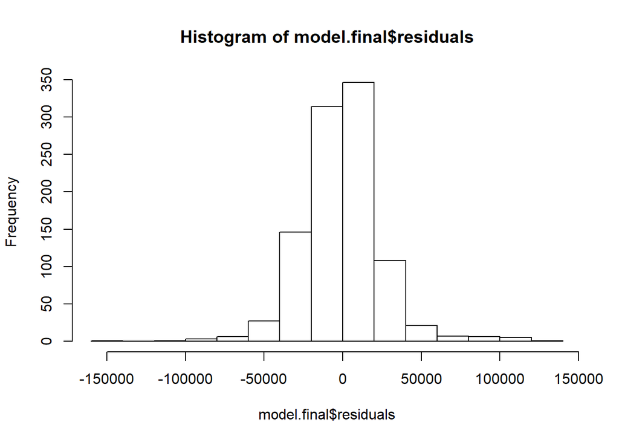

```r
hist(model.final$residuals)
```

### 2.3.2 Section 3.2 Transformation

Did you decide to transform any variables? Why or why not? Explain in a few sentences.

### 2.3.3 Section 3.3 Variable Interaction

Did you decide to include any variable interactions? Why or why not? Explain in a few sentences.

### 2.3.4 Section 3.4 Variable Selection

What method did you use to select the variables you included? Why did you select the method you used? Explain in a few sentences.

I used p-value and AIC methods.

```r
model.full = lm(price ~ ., data = ames_train)
summary(model.full)
```

```
##
## Call:
## lm(formula = price ~ ., data = ames_train)
##
## Residuals:
##     Min      1Q  Median      3Q     Max
## -156889  -14267     -29   12938  133569
##
## Coefficients:
##                         Estimate Std. Error t value Pr(>|t|)
## (Intercept)            3.993e+03  1.381e+04   0.289 0.772488
## Open.Porch.SF         -4.663e+00  1.344e+01  -0.347 0.728659
## Enclosed.Porch        -3.455e+01  1.467e+01  -2.354 0.018756 *
## Pool.Area             -6.998e+01  2.892e+01  -2.420 0.015703 *
## Screen.Porch           3.473e+01  1.597e+01   2.174 0.029932 *
## Overall.Cond           2.921e+03  8.408e+02   3.474 0.000536 ***
## Land.SlopeMod          1.379e+04  5.307e+03   2.598 0.009523 **
## Land.SlopeSev         -2.992e+04  1.499e+04  -1.996 0.046209 *
## Wood.Deck.SF           2.505e+01  7.605e+00   3.294 0.001024 **
## Condition.1Feedr       1.532e+04  6.631e+03   2.310 0.021106 *
## Condition.1Norm        2.406e+04  5.664e+03   4.248 2.37e-05 ***
## Condition.1PosA        2.933e+04  1.088e+04   2.697 0.007120 **
## Condition.1PosN        3.913e+04  1.007e+04   3.886 0.000109 ***
## Condition.1RRAe        1.491e+04  9.642e+03   1.546 0.122482
## Condition.1RRAn        2.625e+04  9.474e+03   2.771 0.005694 **
## Condition.1RRNe       -8.099e+02  1.925e+04  -0.042 0.966444
## Condition.1RRNn       -2.317e+02  1.603e+04  -0.014 0.988469
## Fireplaces             4.484e+03  1.602e+03   2.798 0.005242 **
## Lot.Area               6.381e-01  1.169e-01   5.459 6.10e-08 ***
## Land.ContourHLS        2.070e+04  6.488e+03   3.191 0.001464 **
## Land.ContourLow        7.627e+03  8.479e+03   0.900 0.368585
## Land.ContourLvl        6.286e+03  4.917e+03   1.279 0.201379
## Bldg.Type2fmCon       -1.853e+04  6.161e+03  -3.007 0.002707 **
## Bldg.TypeDuplex       -1.367e+04  4.934e+03  -2.771 0.005689 **
## Bldg.TypeTwnhs        -1.621e+04  4.515e+03  -3.589 0.000348 ***
## Bldg.TypeTwnhsE       -7.332e+03  3.280e+03  -2.235 0.025641 *
## Mas.Vnr.Area           3.099e+01  5.600e+00   5.534 4.06e-08 ***
## BsmtFin.SF.2           3.177e+01  5.441e+00   5.840 7.18e-09 ***
## Bsmt.Unf.SF            1.914e+01  3.013e+00   6.354 3.26e-10 ***
## Kitchen.QualFa        -3.381e+04  7.954e+03  -4.250 2.34e-05 ***
## Kitchen.QualGd        -2.816e+04  4.587e+03  -6.139 1.22e-09 ***
## Kitchen.QualPo        -2.632e+04  2.666e+04  -0.987 0.323877
## Kitchen.QualTA        -3.719e+04  5.161e+03  -7.206 1.17e-12 ***
## Exter.QualFa          -5.851e+04  1.084e+04  -5.399 8.48e-08 ***
## Exter.QualGd          -4.323e+04  6.151e+03  -7.028 4.00e-12 ***
## Exter.QualTA          -5.921e+04  6.839e+03  -8.657  < 2e-16 ***
## Sale.ConditionAdjLand -1.127e+04  1.968e+04  -0.573 0.567026
## Sale.ConditionAlloca   1.913e+04  1.361e+04   1.405 0.160338
## Sale.ConditionFamily  -1.688e+04  7.279e+03  -2.319 0.020609 *
## Sale.ConditionNormal   1.073e+04  3.528e+03   3.042 0.002416 **
## Sale.ConditionPartial  4.171e+04  4.846e+03   8.606  < 2e-16 ***
## Overall.Qual           1.380e+04  1.089e+03  12.670  < 2e-16 ***
## BsmtFin.SF.1           4.869e+01  2.898e+00  16.802  < 2e-16 ***
## area                   4.802e+01  2.645e+00  18.156  < 2e-16 ***
## ---
## Signif. codes:  0 '***' 0.001 '**' 0.01 '*' 0.05 '.' 0.1 ' ' 1
##
## Residual standard error: 25770 on 948 degrees of freedom
## Multiple R-squared:  0.9056, Adjusted R-squared:  0.9013
## F-statistic: 211.5 on 43 and 948 DF,  p-value: < 2.2e-16
```

### 2.3.5 Section 3.5 Model Testing

How did testing the model on out-of-sample data affect whether or how you changed your model? Explain in a few sentences.

There were no overfitting.

## 2.4 Part 4 Final Model Assessment

### 2.4.1 Section 4.1 Final Model Residual

For your final model, create and briefly interpret an informative plot of the residuals.

### 2.4.2 Section 4.2 Final Model RMSE

For your final model, calculate and briefly comment on the RMSE.

### 2.4.3 Section 4.3 Final Model Evaluation

What are some strengths and weaknesses of your model?

### 2.4.4 Section 4.4 Final Model Validation

Testing your final model on a separate, validation data set is a great way to determine how your model will perform in real-life practice.

You will use the “ames_validation” dataset to do some additional assessment of your final model. Discuss your findings, be sure to mention: * What is the RMSE of your final model when applied to the validation data?  
* How does this value compare to that of the training data and/or testing data? * What percentage of the 95% predictive confidence (or credible) intervals contain the true price of the house in the validation data set?  
* From this result, does your final model properly reflect uncertainty?

```r
load("ames_validation.Rdata")
```

```r
ames_validation = ames_validation %>%
  dplyr::select(price, Open.Porch.SF, Enclosed.Porch, Pool.Area, Screen.Porch, Overall.Cond, Land.Slope, Wood.Deck.SF, Condition.1, Fireplaces, Lot.Area, Land.Contour, Bldg.Type, Mas.Vnr.Area, BsmtFin.SF.2, Bsmt.Unf.SF, Kitchen.Qual, Exter.Qual, Sale.Condition, Overall.Qual, BsmtFin.SF.1, area)
```

```r
summary(ames_validation)
```

```
##      price        Open.Porch.SF    Enclosed.Porch     Pool.Area
##  Min.   : 35000   Min.   :  0.00   Min.   :  0.00   Min.   :  0.000
##  1st Qu.:128000   1st Qu.:  0.00   1st Qu.:  0.00   1st Qu.:  0.000
##  Median :157000   Median : 24.00   Median :  0.00   Median :  0.000
##  Mean   :172264   Mean   : 46.43   Mean   : 22.41   Mean   :  1.972
##  3rd Qu.:202000   3rd Qu.: 67.50   3rd Qu.:  0.00   3rd Qu.:  0.000
##  Max.   :584500   Max.   :570.00   Max.   :584.00   Max.   :576.000
##
##   Screen.Porch     Overall.Cond   Land.Slope  Wood.Deck.SF     Condition.1
##  Min.   :  0.00   Min.   :2.000   Gtl:723    Min.   :  0.00   Norm   :653
##  1st Qu.:  0.00   1st Qu.:5.000   Mod: 38    1st Qu.:  0.00   Feedr  : 39
##  Median :  0.00   Median :5.000   Sev:  2    Median :  0.00   Artery : 31
##  Mean   : 16.78   Mean   :5.644              Mean   : 97.01   RRAn   : 14
##  3rd Qu.:  0.00   3rd Qu.:6.000              3rd Qu.:169.50   PosN   : 11
##  Max.   :576.00   Max.   :9.000              Max.   :870.00   RRAe   :  7
##                                                               (Other):  8
##    Fireplaces        Lot.Area     Land.Contour  Bldg.Type    Mas.Vnr.Area
##  Min.   :0.0000   Min.   : 1476   Bnk: 31      1Fam  :632   Min.   :   0.00
##  1st Qu.:0.0000   1st Qu.: 7500   HLS: 27      2fmCon: 23   1st Qu.:   0.00
##  Median :0.0000   Median : 9547   Low: 12      Duplex: 29   Median :   0.00
##  Mean   :0.5701   Mean   : 9894   Lvl:693      Twnhs : 27   Mean   :  93.66
##  3rd Qu.:1.0000   3rd Qu.:11292                TwnhsE: 52   3rd Qu.: 147.75
##  Max.   :3.0000   Max.   :70761                             Max.   :1159.00
##                                                             NA's   :3
##   BsmtFin.SF.2      Bsmt.Unf.SF     Kitchen.Qual Exter.Qual Sale.Condition
##  Min.   :   0.00   Min.   :   0.0   Ex: 41       Ex: 21     Abnorml:  0
##  1st Qu.:   0.00   1st Qu.: 216.0   Fa: 23       Fa: 10     AdjLand:  0
##  Median :   0.00   Median : 441.0   Gd:281       Gd:230     Alloca :  0
##  Mean   :  60.69   Mean   : 550.8   Po:  0       TA:502     Family :  0
##  3rd Qu.:   0.00   3rd Qu.: 810.0   TA:418                  Normal :763
##  Max.   :1393.00   Max.   :1967.0                           Partial:  0
##
##   Overall.Qual     BsmtFin.SF.1         area
##  Min.   : 1.000   Min.   :   0.0   Min.   : 498
##  1st Qu.: 5.000   1st Qu.:   0.0   1st Qu.:1094
##  Median : 6.000   Median : 354.0   Median :1432
##  Mean   : 5.965   Mean   : 415.8   Mean   :1463
##  3rd Qu.: 7.000   3rd Qu.: 679.0   3rd Qu.:1715
##  Max.   :10.000   Max.   :1972.0   Max.   :3820
##
```

```r
sapply(ames_validation, function(x) sum(is.na(x)))
```

```
##          price  Open.Porch.SF Enclosed.Porch      Pool.Area   Screen.Porch
##              0              0              0              0              0
##   Overall.Cond     Land.Slope   Wood.Deck.SF    Condition.1     Fireplaces
##              0              0              0              0              0
##       Lot.Area   Land.Contour      Bldg.Type   Mas.Vnr.Area   BsmtFin.SF.2
##              0              0              0              3              0
##    Bsmt.Unf.SF   Kitchen.Qual     Exter.Qual Sale.Condition   Overall.Qual
##              0              0              0              0              0
##   BsmtFin.SF.1           area
##              0              0
```

```r
summarise.1 = ames_validation %>%
  filter(!is.na(Mas.Vnr.Area)) %>%
  summarise(mean = mean(Mas.Vnr.Area), median = median(Mas.Vnr.Area))

ames_validation = ames_validation %>%
  mutate(Mas.Vnr.Area = ifelse(is.na(Mas.Vnr.Area), summarise.1$median, Mas.Vnr.Area))
```

```r
# Extract Predictions
predict.validation <- predict(model.best, ames_validation)

resid.validation <- ames_validation$price - predict.validation

# Calculate RMSE
resid.validation <- sqrt(mean(resid.validation^2))
resid.validation
```

```
## [1] 24036.23
```

## 2.5 Part 5 Conclusion

Provide a brief summary of your results, and a brief discussion of what you have learned about the data and your model.

In conclusion, to do a good model it is necessary understand the data using EDA. The hard work is in preprocessing data.